# Δημιουργία εκπαιδευτικού υλικού για την εκμάθηση της γλώσσας προγραμματισμού R

# Μάθημα 1ο - Εγκατάσταση Λογισμικού

## Εγκατάσταση της R στα Windows

**Οδηγίες Εγκατάστασης της R**

[video not shown]

1. Μεταβείτε στον επίσημο ιστότοπο του προγραμματισμού R, http://www.R-project.org
2. Κάντε κλικ στον σύνδεσμο CRAN
3. Επιλέξτε mirror

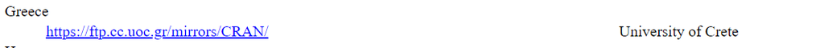

4. Κάντε κλικ στο “Download R for Windows”
5. Κάντε κλικ στον σύνδεσμο που πραγματοποιεί λήψη της βασικής διανομής Base
6. Κάντε κλικ στο Download R 4.0.4 for Windows

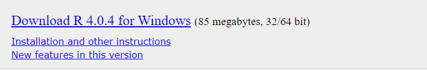

7. Εκτελέστε το αρχείο και ακολουθήστε τα βήματα στις οδηγίες για να εγκαταστήσετε το R.

## Εγκατάσταση του R Studio

[video not shown]

Το **RStudio** είναι το πιο δημοφιλές IDE για την εκτέλεση προγραμμάτων R και διαθέτει δωρεάν άδεια χρήσης. Η διαδικασία εγκατάστασης είναι απλή στα Windows.

• Πηγαίνετε σε αυτήν την σελίδα http://www.rstudio.com/products/rstudio/download/  
• Επιλέξτε τον **installer για Windows** και κατεβάστε το.  
• Δεξί κλικ στο πακέτο -> run as administrator.  
Ακολουθήστε τις οδηγίες και κάντε την εγκατάσταση  
*Σημείωση η R πρέπει να είναι εγκατεστημένη στο σύστημά σας πριν εκτελέσετε το RStudio.*  
Αφού εγκαταστήσετε το RStudio και το ανοίξετε για πρώτη φορά, θα σας ζητήσει να επιλέξετε ποια έκδοση του R θα χρησιμοποιήσετε.

[figure not shown]

Τώρα μπορείτε να δείτε το R Script Editor όπου μπορείτε να πληκτρολογήσετε και να αποθηκεύσετε προγράμματα της R που εκτείνονται σε πολλές γραμμές. Το RStudio δεν είναι απλώς ένα πρόγραμμα επεξεργασίας κειμένου αλλά ένα IDE που σας βοηθά να εκτελείτε και να εντοπίζετε σφάλματα στην R Script με ευκολία.  
Το R Studio GUI χωρίζεται σε 4 μεγάλες ενότητες όπως φαίνεται στο παρακάτω στιγμιότυπο οθόνης:

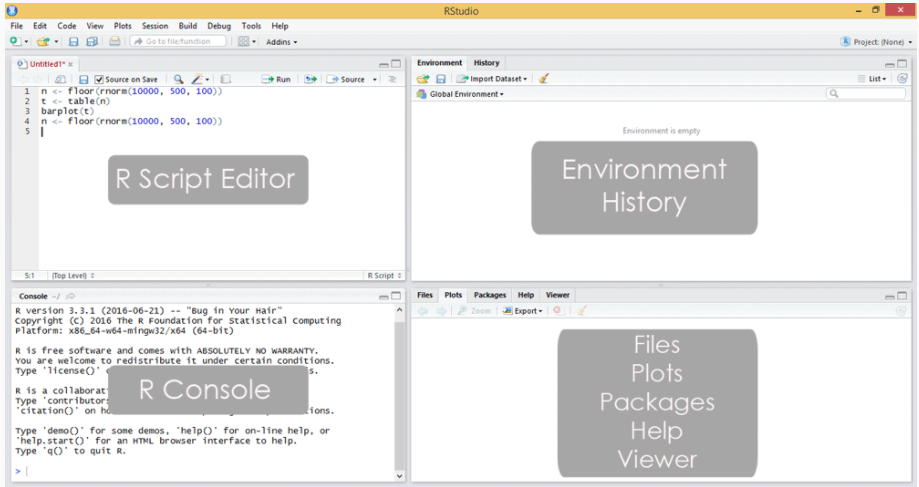

## R Studio – Cloud

1. Πηγαίνετε σε αυτήν την σελίδα http://rstudio.cloud
2. Επιλέξτε Sing Up
3. Το R Studio Cloud έχει δημιουργήσει ένα δικό σας χώρο στο cloud.
4. Ξεκινήστε δημιουργώντας ένα νέο Project
5. Στο menu files επιλέξτε new file => R script

## Το πρώτο μας πρόγραμμα σε R

[video not shown]

Στο πρώτο μας πρόγραμμα R θα παράγουμε 10.000 αριθμούς σε μια τυχαία κατανομή, θα τους οργανώσουμε με βάση τη συχνότητα και θα δημιουργήσουμε το πρώτο μας γράφημα ράβδων. Η πρώτη γραμμή η συνάρτηση `rnorm()` δημιουργεί μια λίστα με 10000 τυχαίους αριθμούς σε κανονική κατανομή έτσι ώστε ο μέσος όρος αυτών των αριθμών να είναι 500 και τυπική απόκλιση 100. Η συνάρτηση `floor()` παίρνει μόνο το ακέραιο μέρος από κάθε αριθμό της λίστας και αφαιρεί το δεκαδικό ψηφίο. Η συνάρτηση `table()` παίρνει αυτούς τους 10000 αριθμούς και μετρά τη συχνότητα του καθενός.

```r
n <- floor(rnorm(10000, 500, 100))
t <- table(n)
```

Η συνάρτηση `barplot()` παίρνει τον πίνακα με τις συχνότητες και δημιουργεί ένα γράφημα ράβδων από τα δεδομένα.

[figure not shown]

Στην πραγματικότητα δεν χρειαζόμαστε 3 γραμμές. Σε μία μόνο γραμμή, θα μπορούσαμε να κάνουμε το ίδιο, προσθέτοντας επιπλέον και ετικέτες στους άξονες x και y :

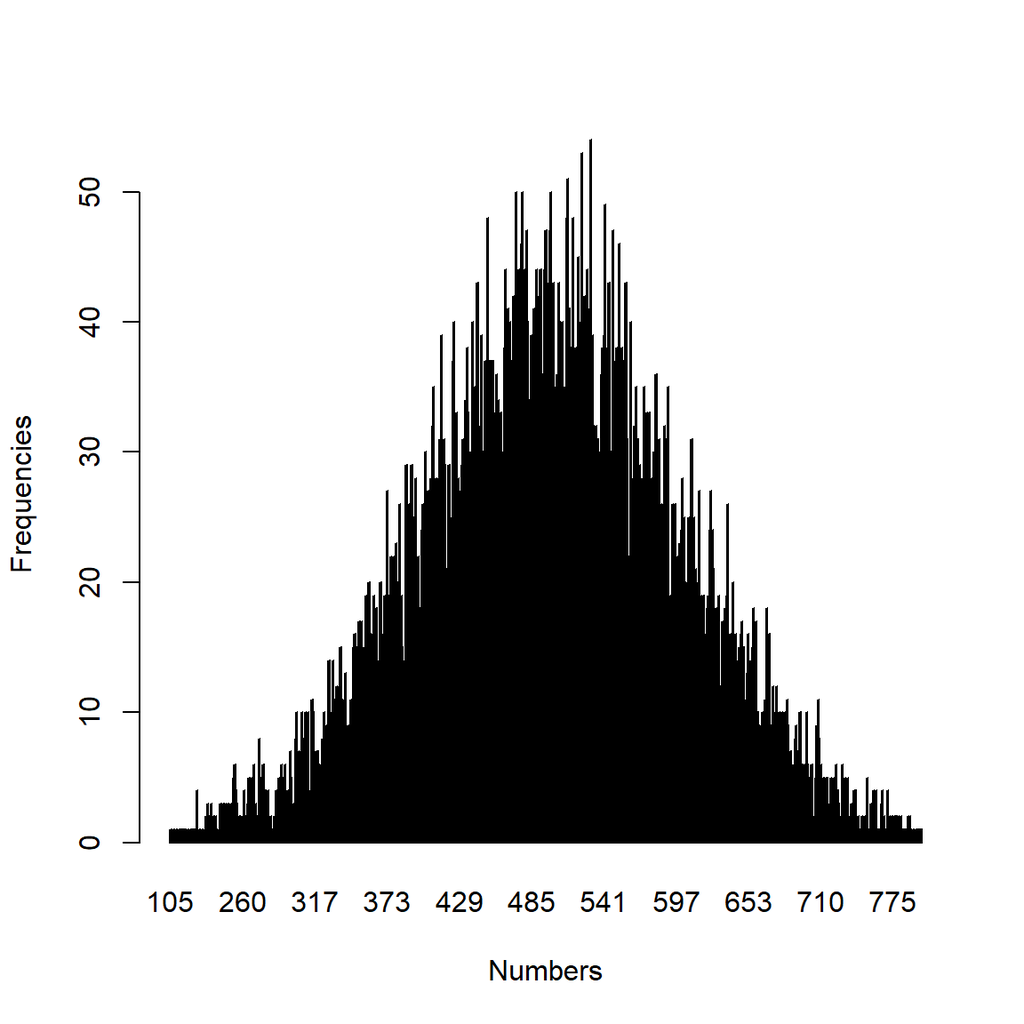

```r
barplot(table(floor(rnorm(10000, 500, 100))), xlab="Numbers", ylab="Frequencies")
```

# Μάθημα 2ο - Βασικοί κανόνες

[video not shown]

## Μαθηματικές Πράξεις

Ο πίνακας περιγράφει για την κάθε μαθηματική πράξη τον τρόπος απεικόνισης στην R

| Μαθηματική Πράξη | Απεικόνιση σε R |
| --- | --- |
| Πρόσθεση | 8+3 |
| Αφαίρεση | 8-3 |
| Πολλαπλασιασμός | 8*3 |
| Διαίρεση | 8/3 |
| Δύναμη | 8^3 |
| Modulus | 8%%3 |
| Απόλυτη Τιμή | abs(-8) |
| Τετραγωνική ρίζα | sqrt(4) |
| Εκθετικό | exp(4) |
| Φυσ λογάριθμος | log(8) |
| Ημίτονο | sin(pi) |
| Συνημίτονο | cos(pi) |

## Μεταβλητές και κανόνες

Η Μεταβλητή συμβολίζει ένα τυχαίο στοιχείο ενός συνόλου. Σε μια μεταβλητή μπορούμε να αποθηκεύσουμε μια αξία (value). Αποθηκεύει δηλαδή μια πληροφορία. Μπορούμε να την καλέσουμε αν γράψουμε στην κονσόλα το όνομά της. Δεν απαιτείται εκ των προτέρων ορισμός του τύπου της κάθε μεταβλητής. Για την ονομασία των μεταβλητών μπορούμε να χρησιμοποιήσουμε γράμματα κεφαλαία και μικρά του λατινικού αλφαβήτου, δηλαδή **“A-Z”,”a-z”,** αριθμούς **“0-9”,** τελεία **”.”** και κάτω παύλα “”.  
Οι μεταβλητές δεν πρέπει να περιέχουν κενά.  
Οι μεταβλητές θα πρέπει να ξεκινούν με γράμμα ή τελεία.  
Δεν μπορούμε να χρησιμοποιήσουμε σαν μεταβλητές λέξεις κλειδιά τις οποίες χρησιμοποιεί η R. Αυτές είναι «if, else, repeat, while, break, in, function, for, next, NULL, FALSE, TRUE, NA, NaN, Inf, NA_integer, NA_real_, NA_complex_ , NA_character».

Αυτή η λίστα είναι διαθέσιμη πληκτρολογώντας `help(reserved)` ή `?reserved` στη γραμμή εντολών της R.

Χρήσιμες πληροφορίες : * TRUE και FALSE είναι οι λογικές σταθερές στην R.  
* NULL αντιπροσωπεύει την απουσία μιας τιμής ή μιας απροσδιόριστης τιμής.  
* Inf είναι για το “Infinity”, για παράδειγμα όταν το 1 διαιρείται με το 0 ενώ NaN για το “Not a Number”, για παράδειγμα όταν το 0 διαιρείται με το 0.  
* NA σημαίνει “Μη Διαθέσιμο” και χρησιμοποιείται για την αναπαράσταση των τιμών που λείπουν.  
* H R είναι case sensitive που σημαίνει ότι TRUE και True δεν είναι το ίδιο. To TRUE είναι μια δεσμευμένη λέξη που δηλώνει μια λογική σταθερά στο R και True μπορεί να χρησιμοποιηθεί σαν όνομα μεταβλητής.

## Βασικές κατηγορίες αντικειμένων *«Atomic»* Classes

**Αριθμοί** : Μπορεί να είναι τύπου integer, double ή complex. Στην R μπορεί να ελεγχθεί με τη συνάρτηση `typeof()`.  
Οι αριθμητικές σταθερές που ακολουθούνται από `L` θεωρούνται integer και αυτές που ακολουθούνται `i` θεωρούνται complex.

```r
typeof(5)
```

```
[1] "double"
```

```r
typeof(5L)
```

```
[1] "integer"
```

```r
typeof(5i)
```

```
[1] "complex"
```

Οι αριθμοί που προηγούνται 0x ή 0X ερμηνεύονται ως δεκαεξαδικοί αριθμοί.

```r
0xff
```

```
[1] 255
```

```r
0XF + 1
```

```
[1] 16
```

**Χαρακτήρες** : Οι χαρακτήρες μπορούν να αναπαρασταθούν χρησιμοποιώντας είτε μεμονωμένα εισαγωγικά (’) είτε με διπλά εισαγωγικά (").

```r
'example'
```

```
[1] "example"
```

```r
typeof("1")
```

```
[1] "character"
```

**Λογικοί** : Οι λογικοί μπορούν να αναπαραχθούν με τις δεσμευμένες λέξεις `TRUE` ή `T` και `FALSE` ή `F`.

**Λογικοί Τελεστές**  
Οι λογικοί τελεστές έχουν δύο πιθανές τιμές , `TRUE` ή `FALSE`.

| Τελεστής | Απεικόνιση στην R |
| --- | --- |
| Ίσον `==` | equal |
| Όχι ίσο `!=` | not equal |
| Μικρότερο Από `<` | less than |
| Μεγαλύτερο από `>` | grander than |
| Μικρότερο ή ίσο από `<=` | less or equal |
| Μεγαλύτερο ή ίσο `>=` | grander or equal |
| Όχι `!` | not |
| Ή `\|` | or |
| Και `&` | and |

## Ενσωματωμένες μεταβλητές (built in variables)

Η R έχει έναν αριθμό ενσωματωμένων μεταβλητών. Συγκεκριμένα, έχει διαθέσιμες τις παρακάτω :  
• LETTERS: Τα 26 κεφαλαία λατινικά γράμματα  
• letters: Τα 26 μικρά λατινικά γράμματα  
• month.abb: Συντομογραφία των μηνών  
• month.name: Ονόματα μηνών  
• pi: τιμή του π

# Μάθημα 3ο - Δομές επιλογής και επανάληψης

## Δομές επιλογής

[video not shown]

Η λήψη αποφάσεων είναι ένα σημαντικό μέρος του προγραμματισμού. Αυτό μπορεί να επιτευχθεί στον προγραμματισμό σε R χρησιμοποιώντας τη `if...else`.

**IF**

Η σύνταξη του `if` είναι:

if *(δήλωση αληθείς)* {  
κώδικας  
}

Εάν η δήλωση είναι `TRUE`, τότε εκτελείται ο κώδικάς που έχουμε συμπεριλάβει στις αγκύλες `{}`. Αλλά αν είναι `FALSE`, τότε προσπερνάτε η εκτέλεση του κώδικα.  
Η δήλωση μπορεί να είναι ένα λογικό ή αριθμητικό διάνυσμα, αλλά σε αυτή την περίπτωση ελέγχετε μόνο το πρώτο στοιχείο του διανύσματος.

**If …else**

Σύνταξη της δήλωσης if… else:  
if (Δήλωση αληθείς) {  
κώδικας 1  
} else {  
Κώδικας 2  
}

O κώδικας 2 τρέχει αν η δήλωση είναι `false`. Επιπλέον είναι σημαντικό να σημειωθεί ότι στη δήλωση του `else` πρέπει να είναι στην ίδια γραμμή οι αγκύλες } `else` { .

**Διάγραμμα ροής της δήλωσης if… else**

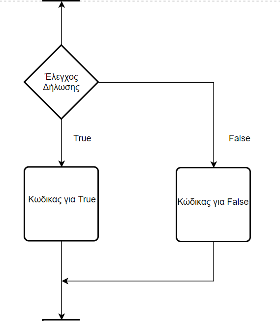

**Παράδειγμα if …else**

```r
x <- -5
if(x > 0) {
    print("Θετικός")
} else {
    print("Αρνητικός")
}
```

```
[1] "Αρνητικός"
```

Η ίδια σύνταξη μπορεί να γίνει σε μία γραμμή, σε αυτή την περίπτωση δεν χρειαζόμαστε καθόλου αγκύλες.

```r
x <- 5
if(x > 0) print("Θετικός") else print("Αρνητικός")
```

```
[1] "Θετικός"
```

**If …else if**

Η δήλωση if … else if μας επιτρέπει να εκτελέσουμε έναν μπλοκ κώδικα για περισσότερες από δύο εναλλακτικές.

**Η σύνταξη είναι :**

if ( δήλωση αληθείς) {  
κώδικας 1  
} else if ( δήλωση αληθείς 2) {  
Κώδικας 2  
} else if ( δήλωση αληθείς 3) {  
Κώδικας 3  
} else {  
Κώδικας 4  
}

Φυσικά και πάλι μόνο μια δήλωση θα εκτελεστεί, η πρώτη που είναι αληθής.

**Παράδειγμα ένθετου if …else**

```r
x <- 0
if (x < 0) {
print("Αρνητικός")
} else if (x > 0) {
print("Θετικός")
} else
print("Μηδέν")
```

```
[1] "Μηδέν"
```

**Ifelse()**

Υπάρχει όμως στην R και ένας ευκολότερος τρόπος να χρησιμοποιηθεί η if …else με την συνάρτηση ifelse() και την χρήση κάποιου διανύσματος. Τα διανύσματα αποτελούν βασικό δομικό στοιχείο στο προγραμματισμό σε R. Οι περισσότερες συναρτήσεις λαμβάνουν ως είσοδο ένα διάνυσμα ή έχουν σαν έξοδο κάποιο διάνυσμα.

**Σύνταξη της συνάρτησης ifelse ()**

ifelse(δήλωση αληθείς, true, false)

Εδώ, η αληθείς δήλωση πρέπει να είναι κάποιο διάνυσμα. Η τιμή επιστροφής είναι ένα διάνυσμα με το ίδιο μήκος με αυτό της δήλωσης.

**Παράδειγμα: συνάρτησης ifelse ()**

```r
a = c(5,7,2,9)
ifelse(a %% 2 == 0,"άρτιος","περιττός")
```

```
[1] "περιττός" "περιττός" "άρτιος"   "περιττός"
```

## Δομές επανάληψης

[video not shown]

Οι δομές επανάληψης loops χρησιμοποιούνται για την επανάληψη ενός συγκεκριμένου κώδικα.

**While**  
Στη R , το «while» επαναλαμβάνει ένα κομμάτι κώδικα για όσες φορές ικανοποιείται μια συγκεκριμένη συνθήκη.

**Σύνταξη `While**  
while (Δήλωση )  
{  
Κώδικας  
}

Η δοθείσα δήλωση αξιολογείται και εκτελείται το σώμα για όσο είναι αληθής. Οι δηλώσεις εντός βρόγχου εκτελούνται και η ροή επιστρέφει στην αρχή του βρόγχου και επαναξιολογεί την «δήλωση», αν είναι αληθείς επαναλαμβάνεται ο βρόγχος μέχρις ότου η «δήλωση» είναι ψευδής οπότε βγαίνει από το βρόγχο.

**Διάγραμμα ροής While**

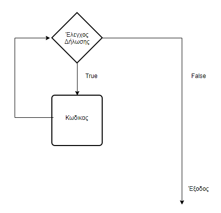

**Παράδειγμα `While**

```r
i <- 1
while (i < 6) {
print(i)
i = i+1
}
```

```
[1] 1
[1] 2
[1] 3
[1] 4
[1] 5
```

To «i» αρχικοποιείται σε 1. Η αρχική «δήλωση» i<6 το αξιολογεί ως true και εκτελείτε το σώμα του βρόγχου που αυξάνει το «i» κατά ένα σε κάθε επανάληψη. Όταν το «i» πάρει την τιμή 6 η δήλωση δίνει false και το while τελειώνει.

**For**  
Το `For` χρησιμοποιείτε για την επανάληψη ενός συγκεκριμένου μπλοκ κώδικα.

**Σύνταξη for**  
for ( i in επαναλήψεις)  
{  
Κώδικας  
}

Οι `επαναλήψεις` είναι ένα διάνυσμα, και το i παίρνει τιμή κατά την διάρκεια εκτελέσεις του βρόγχου σε κάθε επανάληψη.

**Παράδειγμα for**

```r
x <- c(2,3,4,5,6,7)
count <- 0
for (i in x) {
  if(i %% 2 == 0) count = count+1
}
print(count)
```

```
[1] 3
```

Ο παραπάνω βρόγχος εκτελείτε 6 φορές όσα και τα στοιχεία του δοθέντος διανύσματος. Σε κάθε επανάληψη το «i» παίρνει τιμή του αντίστοιχου στοιχείου του διανύσματος. Αρχικά ελέγχετε αν ο αριθμός είναι μονός ή ζυγός και αν είναι ζυγός αυξάνετε ο μετρητής count κατά ένα.

**Repeat**  
To repeat, χρησιμοποιείται για επανάληψη ενός μπλοκ κώδικα πολλές φορές. Δεν υπάρχει κάποια συνθήκη εξόδου από τον βρόγχο. Πρέπει να βάλουμε εμείς μια κατάσταση εξόδου μέσα στον κώδικα του βρόγχου.

**Σύνταξη Repeat** Repeat{  
Κώδικας  
break  
}  
Δηλώνουμε το `break` για να βγούμε από τον βρόγχο.

**Παράδειγμα repeat**

```r
x <- 1
repeat {
   print(x)
   x = x+1
   if (x == 6){
    break
    }
}
```

```
[1] 1
[1] 2
[1] 3
[1] 4
[1] 5
```

Χρησιμοποιήσαμε την συνθήκη για τον έλεγχο εξόδου . Όταν το x πάρει την τιμή 6 τερματίζεται ο βρόγχος και τυπώνονται οι τιμές του x.

# Μάθημα 4ο - Δομές Δεδομένων

**Δομές Δεδομένων της R**

## Διάνυσμα Vector

[video not shown]

Το διάνυσμα είναι μια βασική δομή δεδομένων στην R. Περιέχει στοιχεία του ίδιου τύπου. Οι τύποι δεδομένων μπορεί να είναι λογικοί, ακέραιοι, double, χαρακτήρες ή μικτοί αριθμοί . Μπορείτε να ελέγξετε τον τύπο των δεδομένων με τη `typeof()` συνάρτηση. Μια άλλη σημαντική ιδιότητα ενός διανύσματος είναι το μήκος του. Ο αριθμός των στοιχείων του διανύσματος μπορεί να ελεγχθεί με τη συνάρτηση `length()`. Για την δημιουργία ενός διανύσματος χρησιμοποιείται η συνάρτηση `c()`. Δεδομένου ότι ένα διάνυσμα έχει στοιχεία μόνο του ιδίου τύπου η συνάρτηση αυτή θα “εξαναγκάσει” τα δοθέντα στοιχεία στον ίδιο τύπο.

```r
x <- c(1, 5, 4, 9, 0)
typeof(x)
```

```
[1] "double"
```

Ευρεση αριθμού στοιχείων διανύσματος

```r
length(x)
```

```
[1] 5
```

Εξαναγκασμός σε character

```r
 x <- c(1, 5.4, TRUE, "hello")
typeof(x)
```

```
[1] "character"
```

Αν θέλουμε να δημιουργήσουμε έναν διάνυσμα διαδοχικών αριθμών τότε χρησιμοποιούμε το «:» ως εξής :

```r
x <- 1:7
x
```

```
[1] 1 2 3 4 5 6 7
```

```r
y <- 2:-2
y
```

```
[1]  2  1  0 -1 -2
```

## Λίστα List

[video not shown]

Η λίστα είναι μια δομή δεδομένων που έχει στοιχεία μεικτών τύπων δεδομένων. Ένα διάνυσμα `vector` έχει στοιχεία του ίδιου τύπου μόνο , μια λίστα μπορεί να έχει στοιχεία διαφορετικού τύπου. Η συνάρτηση `typeof()` μας δίνει σαν αποτέλεσμα μια λίστα, και η συνάρτηση `length()` τον αριθμό των διακριτών στοιχείων της. Μία λίστα μπορούμε να τη δημιουργήσουμε με τη συνάρτηση `list()`. Ακολουθεί ένα παράδειγμα μιας λίστας που έχει τρία στοιχεία διαφορετικού τύπου δεδομένων.

**Παράδειγμα:**

```r
x <- list("a" = 2.5, "b" = TRUE, "c" = 1:3)
```

```r
x
```

```
$a
[1] 2.5

$b
[1] TRUE

$c
[1] 1 2 3
```

```r
typeof(x)
```

```
[1] "list"
```

```r
length(x)
```

```
[1] 3
```

Δημιουργήσαμε μια λίστα με τρία στοιχεία με τύπους δεδομένων double, logical και integer αντίστοιχα. Με την συνάρτηση `str()` μπορούμε να πάρουμε μια πιο αναλυτική κατάσταση των στοιχείων της λίστας μας.

```r
str(x)
```

```
List of 3
 $ a: num 2.5
 $ b: logi TRUE
 $ c: int [1:3] 1 2 3
```

Στο παράδειγμα μας , a, b και c ονομάζονται ετικέτες και καθιστούν ευκολότερη την αναφορά στα στοιχεία μιας λίστας. Ωστόσο, οι ετικέτες είναι προαιρετικές, από άποψη καλής προγραμματιστικής πρακτική συνιστάτε η χρήση τους. Μπορούμε να δημιουργήσουμε την ίδια λίστα χωρίς τις ετικέτες ως εξής :

```r
list(2.5,TRUE,1:3)
```

```
[[1]]
[1] 2.5

[[2]]
[1] TRUE

[[3]]
[1] 1 2 3
```

**Πρόσβαση σε στοιχεία μιας λίστας** Μπορείτε να έχετε πρόσβαση σε λίστες με παρόμοιο τρόπο με τα διανύσματα. Ας εξετάσουμε μια λίστα ως εξής:

```r
x<-list(name="Dimitris",plays=c("Football","Running"),age=20)
x["age"] #Επιστρέφει την τιμή
```

```
$age
[1] 20
```

```r
typeof(x["age"])  #Μονό Bracket επιστρέφει τον τύπο της λίστας
```

```
[1] "list"
```

```r
x[["age"]]  #Διπλό bracket επιστρέφει την τιμή
```

```
[1] 20
```

```r
typeof(x[["age"]]) # Διπλό bracket και παρένθεση επιστρέφει τον τύπο του αντικειμένου
```

```
[1] "double"
```

Εναλλακτικά αντί για [[ ]] μπορούμε να χρησιμοποιήσουμε το $ ώς εξής:

```r
x$name
```

```
[1] "Dimitris"
```

```r
x$plays[1]
```

```
[1] "Football"
```

**Τροποποίηση μιας λίστας**

Μπορούμε να αλλάξουμε τα στοιχεία μιας λίστας μέσω εκ νέου ανάθεσης. Μπορούμε δηλαδή να επιλέξουμε οποιαδήποτε από τις τεχνικές πρόσβασης στοιχείων που αναφέραμε παραπάνω για να την τροποποιήσουμε.

**Παράδειγμα**

```r
x$name<-"Elena"
x
```

```
$name
[1] "Elena"

$plays
[1] "Football" "Running"

$age
[1] 20
```

**Διαγραφή στοιχείων από μια λίστα**

Μπορούμε να διαγράψουμε ένα στοιχείο εκχωρώντας τιμή NULL σε αυτό.

```r
x$age<-NULL
x
```

```
$name
[1] "Elena"

$plays
[1] "Football" "Running"
```

## Πίνακας Matrix

[video not shown]

Matrix, πίνακας είναι μια δισδιάστατη δομή δεδομένων στον προγραμματισμό σε R. Είναι παρόμοιο με το διάνυσμα,περιλαμβάνει στοιχεία του **ίδιου είδους** μονο, αλλά περιέχει επιπλέον το χαρακτηριστικό διάστασης. Όλα τα χαρακτηριστικά ενός αντικειμένου μπορούν να ελεγχθούν με τη συνάρτηση `attributes()`. Η διασταση του matrix ελέγχετε με τη συνάρτηση `dim()`.

Μπορούμε να ελέγξουμε εάν μια μεταβλητή είναι ένας πίνακας ή όχι με τη συνάρτηση `class()`.

Δημιουργούμε ένα Matrix χρησιμοποιώντας τη συνάρτηση `matrix()`. Η διάσταση του πίνακα ορίζετε περνώντας τιμές στα ορίσματα nrow και ncol.

**Παράδειγμα:**

```r
x <- matrix(1:9, nrow = 3, ncol = 3)
class(x)
```

```
[1] "matrix" "array"
```

```r
attributes(x)
```

```
$dim
[1] 3 3
```

```r
dim(x)
```

```
[1] 3 3
```

Βλέπουμε ότι ο πίνακας γεμίζει με τα στοιχεία 1:9 με βάση τη στήλη. Αυτό μπορεί να αντιστραφεί με το όρισμα `byrow=TRUE` που γεμίζει τον πίνακα κατά σειρά.

```r
x <- matrix(1:9, nrow=3, byrow=TRUE)
```

Ενα επιπλέον χρήσιμο όρισμα των πινάκων είναι το **dimnames** όπου μπορείτε να ονομάσετε τις σειρές και τις στήλες του πίνακα κατά τη δημιουργία, περνώντας μια λίστα 2 στοιχείων στο όρισμα.

```r
x <- matrix(1:9, nrow = 3, dimnames = list(c("X","Y","Z"), c("A","B","C")))
```

Μπορείτε να αποκτήσετε πρόσβαση ή να τροποποιήσετε τα ονόματα με δύο χρήσιμες συναρτήσεις `colnames()` και `rownames()`.

```r
colnames(x)
```

```
[1] "A" "B" "C"
```

```r
rownames(x)
```

```
[1] "X" "Y" "Z"
```

```r
colnames(x) <- c("a1","a2","a3")
rownames(x) <- c("b1","b2","b3")
```

Ένας άλλος τρόπος δημιουργίας ενός πίνακα είναι με τη χρήση των συναρτήσεων `cbind()` και `rbind()`.

**Παράδειγμα:**

```r
#Συμπλήρωση by column
cbind(c(1,2,3),c(4,5,6),c(7,8,9))
```

```
     [,1] [,2] [,3]
[1,]    1    4    7
[2,]    2    5    8
[3,]    3    6    9
```

```r
#Συμπληρωση by row
rbind(c(1:3),c(4:6),c(7:9))
```

```
     [,1] [,2] [,3]
[1,]    1    2    3
[2,]    4    5    6
[3,]    7    8    9
```

Τέλος, μπορείτε επίσης να δημιουργήσετε έναν νέο πίνακα από ένα διάνυσμα ρυθμίζοντας τη διάστασή του, χρησιμοποιώντας την συνάρτηση `dim()`.

```r
x <- c(1,2,3,4,5,6,7,8,9)
x
```

```
[1] 1 2 3 4 5 6 7 8 9
```

```r
class(x)
```

```
[1] "numeric"
```

```r
dim(x) <- c(3,3) # Μπορούμε να βάλουμε διαστάσεις σε ένα vector
x
```

```
     [,1] [,2] [,3]
[1,]    1    4    7
[2,]    2    5    8
[3,]    3    6    9
```

```r
class(x)
```

```
[1] "matrix" "array"
```

**Πρόσβαση σε στοιχεία ενός πίνακα**

Μπορούμε να έχουμε πρόσβαση σε στοιχεία ενός πίνακα χρησιμοποιώντας της []. Δεν ξεχνάμε όμως ότι στους πίνακες οι γραμμές (rows) και οι στήλες (columns) είναι διανύσματα.

**Με χρήση ακέραιου διανύσματος**

Ορίζουμε τα στοιχεία των γραμμών και τα στοιχεία των στηλών που θα χρησιμοποιήσουμε.

Μπορούμε να χρησιμοποιήσουμε αρνητικούς ακέραιους αριθμούς για να καθορίσουμε τις γραμμές ή τις στήλες που θα εξαιρεθούν.

**Παράδειγμα:**

```r
x <- matrix(1:9, nrow = 3, dimnames = list(c("X","Y","Z"), c("A","B","C")))
```

Eπιλέγονται οι γραμμές 1 & 2 και οι στήλες 2 & 3

```r
x[c(1,2),c(2,3)]
```

```
  B C
X 4 7
Y 5 8
```

Eπιλέγονται οι γραμμές 2,1 και όλες οι στήλες

```r
x[c(2,1),]
```

```
  A B C
Y 2 5 8
X 1 4 7
```

Επιλογή όλων

```r
x[,]
```

```
  A B C
X 1 4 7
Y 2 5 8
Z 3 6 9
```

Επιλογή όλων των γραμμών εκτός της 1ης

```r
x[-1,]
```

```
  A B C
Y 2 5 8
Z 3 6 9
```

Επιλογή μόνο μιας γραμμής

```r
x[1,]
```

```
A B C
1 4 7
```

Επιλογή μόνο μιας στήλης

```r
x[,1]
```

```
X Y Z
1 2 3
```

Αυτό που πρέπει να προσέξουμε εδώ είναι ότι κατα την επιλογή μιας γραμμής ή στήλης το αποτέλεσμα δίνεται ως διάνυσμα και όχι σαν πίνακας.

```r
class(x[1,])
```

```
[1] "integer"
```

Αυτό μπορεί να αποφευχθεί χρησιμοποιώντας το όρισμα drop = FALSE ως εξής:

```r
x[1,,drop=FALSE]
```

```
  A B C
X 1 4 7
```

Τώρα το αποτέλεσμά μας είναι ένας πίνακας 1x3 και όχι ένα διάνυσμα. H συνάρτηση `class()` επιστρέφει matrix.

```r
class(x[1,,drop=FALSE])
```

```
[1] "matrix" "array"
```

**Με χρήση λογικού διανύσματος**

Μπορούμε να δηλώσουμε για την κάθε γραμμή και στήλη αν θα επιστραφούν οι τιμές τους ή όχι, με `TRUE` επιστρέφονται και με `FALSE` όχι.

**Παράδειγμα:**

```r
x
```

```
  A B C
X 1 4 7
Y 2 5 8
Z 3 6 9
```

```r
#Επιστρέφει τις γραμμές 1 & 3 και τις στήλες 2 & 3
x[c(TRUE,FALSE,TRUE),c(FALSE,TRUE,TRUE)]
```

```
  B C
X 4 7
Z 6 9
```

Μπορούμε να αναμίξουμε λογικές τιμές με ακεραίους.

```r
x[c(TRUE,FALSE,TRUE),c(2,3)]
```

```
  B C
X 4 7
Z 6 9
```

**Επιλογή στοιχείων με συνθήκη**

Επιλέγονται τα στοιχεία >2.

```r
x[x>2]
```

```
[1] 3 4 5 6 7 8 9
```

Επιλογή μονών αριθμών.

```r
x[x%%2 != 0]
```

```
[1] 1 3 5 7 9
```

**Με διάνυσμα χαρακτήρων**

Μπορούμε να προσπελάσουμε έναν πίνακα χρησιμοποιώντας τα ονόματα των γραμμών και στηλών. Μπορούμε επίσης να αναμείξουμε λογικούς, ακέραίους και χαρακτήρες.

**Παράδειγμα:**

```r
x[,"A"]
```

```
X Y Z
1 2 3
```

```r
x[TRUE,c("A","C")]
```

```
  A C
X 1 7
Y 2 8
Z 3 9
```

```r
x[2:3,c("A","C")]
```

```
  A C
Y 2 8
Z 3 9
```

**Τροποποίηση των στοιχείων ενός πίνακα :**

Χρησιμοποιώντας τον τελεστή ανάθεσης τιμής με κάποιον από τους παραπάνω τρόπους προσπέλασης μπορούμε να τροποποιήσουμε τα στοιχεία ενός πίνακα.

**Παράδειγμα:**

```r
x
```

```
  A B C
X 1 4 7
Y 2 5 8
Z 3 6 9
```

```r
x[2,2] <- 10; x    # Αλλαγή τιμής στο στοιχείο της θέσης 2,2
```

```
  A  B C
X 1  4 7
Y 2 10 8
Z 3  6 9
```

```r
x[x<3] <- 0; x    # Αλλαγή τιμής σε όλα τα στοιχεία μικρότερα του 3
```

```
  A  B C
X 0  4 7
Y 0 10 8
Z 3  6 9
```

**Συνάρτηση `t()` transpose**

Η συνάρτηση transpose αλλάζει τις γραμμές με τις στήλες:

```r
t(x)
```

```
  X  Y Z
A 0  0 3
B 4 10 6
C 7  8 9
```

Προσθήκη νέας γραμμής ή στήλης μπορούμε να κάνουμε με τις συναρτήσεις `rbind()` και `cbind()`.

```r
y<-rbind(x,c(20,21,22))        # Προσθήκη γραμμής
y<-cbind(y, c(10,11,12,13))    # Προσθήκη στήλης
y
```

```
   A  B  C
X  0  4  7 10
Y  0 10  8 11
Z  3  6  9 12
  20 21 22 13
```

Διαγραφή γραμμής 4.

```r
y <- y[1:3,];
y
```

```
  A  B C
X 0  4 7 10
Y 0 10 8 11
Z 3  6 9 12
```

Η διάσταση του πίνακα μπορεί να αλλάξει χρησιμοποιώντας τη `dim()` συνάρτηση, dimension όπου δηλώνουμε νέα διάταξη στηλών και γραμμών, πρέπει βέβαια να απεικονίζονται στην νέα διάταξη όλα τα στοιχεία. Δηλαδή αν έχουμε έναν πίνακα 3Χ4 = 12 στοιχεία η νέα διάταξη θα πρέπει να περιλαμβάνει 12 στοιχεία (12x1, 6x2…).

```r
dim(y) <- c(2,6);
y
```

```
     [,1] [,2] [,3] [,4] [,5] [,6]
[1,]    0    3   10    7    9   11
[2,]    0    4    6    8   10   12
```

## Παράγοντες Factors

[video not shown]

Factors είναι μια δομή δεδομένων που χρησιμοποιείται για πεδία που λαμβάνουν μόνο προκαθορισμένο, πεπερασμένο αριθμό τιμών (κατηγορηματικά δεδομένα). Για παράδειγμα: ένα πεδίο δεδομένων όπως η οικογενειακή κατάσταση μπορεί να περιέχει μόνο τις τιμές άγγαμος, έγγαμος, διεζευγμένος και χήρος. Οι διακριτές αυτές τιμές ονομάζονται επίπεδα.

**Παράδειγμα:** Δημιουργούμε εναν νέο factor με τη συνάρτηση factor().

```r
f <- factor(c("single", "married", "married", "single"))
class(f)
```

```
[1] "factor"
```

```r
levels(f)
```

```
[1] "married" "single"
```

O factor f έχει τέσσερα στοιχεία και δύο επίπεδα. Μπορούμε να ελέγξουμε αν μια μεταβλητή είναι factor με την συνάρτηση class() και τα επίπεδα με τη συνάρτηση levels().

Οι factors σχετίζονται στενά με τα διανύσματα. Στην πραγματικότητα, οι factors αποθηκεύονται ως ακέραια διανύσματα. Αυτό φαίνεται καθαρά από τη δομή τους.

```r
str(f)
```

```
 Factor w/ 2 levels "married","single": 2 1 1 2
```

Τα επίπεδα τους αποθηκεύονται σε ένα διάνυσμα χαρακτήρων και τα μεμονωμένα στοιχεία αποθηκεύονται στην πραγματικότητα ως δείκτες.

Οι factors δημιουργούνται επίσης όταν διαβάζουμε μη αριθμητικές στήλες σε ένα data frame.

**Πρόσβαση στα στοιχεία ενός factor**

```r
f
```

```
[1] single  married married single
Levels: married single
```

```r
f[3]           # Πρόσβαση στο 3ο στοιχείο
```

```
[1] married
Levels: married single
```

```r
f[c(3, 4)]     # Πρόσβαση στο 3ο  και στο 4ο στοιχείο
```

```
[1] married single
Levels: married single
```

```r
f[-1]          # Πρόσβαση σε όλα εκτός του 1ου στοιχείου
```

```
[1] married married single
Levels: married single
```

```r
f[c(TRUE, FALSE, TRUE, TRUE)]  # Πρόσβαση με χρήση λογικών μεταβλητών
```

```
[1] single  married single
Levels: married single
```

**Τροποποίηση στοιχείων ενός factor**

Τα στοιχεία ενός factor μπορούν να τροποποιηθούν χρησιμοποιώντας απλές αναθέσεις. Δεν μπορούμε όμως να επιλέξουμε τιμές εκτός των προκαθορισμένων levels.

```r
f[2] <- "single"    # Αναθεση τιμής στη 2η θέση
f
```

```
[1] single  single  married single
Levels: married single
```

```r
f[3] <- "widowed"    # Τιμή εκτός levels δεν μπορεί να γίνει ανάθεση
```

**Προσοχη** η θέση που κάνουμε ανάθεση γίνετε NA μετά την αποτυχημένη ανάθεση τιμής.

Η λύση είναι να προσθέσετε πρώτα την νέα τιμή στο factor.

```r
levels(f) <- c(levels(f), "widowed")    # προσθήκη επιπέδου
f[3] <- "widowed" #Ανάθεση τιμής
f
```

```
[1] single  single  widowed single
Levels: married single widowed
```

## Πολυδιάστατοι πίνακες Arrays

[video not shown]

Τα Arrays είναι τα αντικείμενα δεδομένων R που μπορούν να αποθηκεύσουν δεδομένα σε περισσότερες από δύο διαστάσεις. Για παράδειγμα αν δημιουργήσουμε έναν πίνακα διαστάσεων (2, 3, 4) τότε δημιουργεί 4 ορθογώνιους πίνακες ο καθένας με 2 σειρές και 3 στήλες. Τα Arrays μπορούν να αποθηκεύσουν τον ίδιο τύπο δεδομένων σε όλα τα δεδομένα τους.

Δημιουργείται χρησιμοποιώντας τη συνάρτηση `array()` .

```r
# Δημιουργούμε τα παρακάτω διανύσματα
vector1 <- c(5,9,3)
vector2 <- c(10,11,12,13,14,15)
```

```r
# Δημιουργούμε ένα νέο array με διαστασεις 3Χ3 η τελευταία επιλογή στην
# διάσταση είναι 2 οπότε έχουμε δισδιάστατο Array
my_Array <- array(c(vector1,vector2),dim = c(3,3,2))
my_Array
```

```
, , 1

     [,1] [,2] [,3]
[1,]    5   10   13
[2,]    9   11   14
[3,]    3   12   15

, , 2

     [,1] [,2] [,3]
[1,]    5   10   13
[2,]    9   11   14
[3,]    3   12   15
```

**Ονομασία στηλών και σειρών**

Μπορούμε να δώσουμε ονόματα στις σειρές, τις στήλες και τους πίνακες στον πίνακα χρησιμοποιώντας την παράμετρο `dimnames` .

```r
#Δημιουργούμε τα παρακάτω διανύσματα
column.names <- c("COL1","COL2","COL3") #Ονοματα στηλών
row.names <- c("ROW1","ROW2","ROW3") # Ονόματα γραμμών
matrix.names <- c("Matrix1","Matrix2") # Ονομάτα διαστάσεων
```

```r
my_Array <- array(c(vector1,vector2),dim = c(3,3,2),
              dimnames = list(row.names,column.names,matrix.names))
print(my_Array)
```

```
, , Matrix1

     COL1 COL2 COL3
ROW1    5   10   13
ROW2    9   11   14
ROW3    3   12   15

, , Matrix2

     COL1 COL2 COL3
ROW1    5   10   13
ROW2    9   11   14
ROW3    3   12   15
```

**Πρόσβαση στα στοιχεία του Array

```r
# Εκτύπωσε την 3η γραμμή του 2ου πίνακα
print(my_Array[3,,2])
```

```
COL1 COL2 COL3
   3   12   15
```

```r
# Εκτύπωσε το 1ο στοιχείο της 3ης στήλης του 1ου πίνακα
print(my_Array[1,3,1])
```

```
[1] 13
```

```r
# Εκτύπωσε τον 2ο πίνακα
print(my_Array[,,2])
```

```
     COL1 COL2 COL3
ROW1    5   10   13
ROW2    9   11   14
ROW3    3   12   15
```

## Πλαίσια δεδομένων Data frames

[video not shown]

Το πλαίσιο δεδομένων είναι μια δισδιάστατη δομή δεδομένων στην R με μορφή πίνακα. Κάθε στοιχείο καταλαμβάνει μια στηλη και οι τιμές των στοιχείων εμφανίζονται στις σειρές. Μπορούμε να ελέγξουμε αν μια μεταβλητή είναι ένα πλαίσιο δεδομένων με την συνάρτηση `class()`. Μπορούμε να δημιουργήσουμε ένα πλαίσιο δεδομένων χρησιμοποιώντας τη συνάρτηση `data.frame()`.

**Βασικές εντολές data frame**

```r
x <- data.frame("SN" = 1:2, "Age" = c(20,10), "Name" = c("John","Elen"))
str(x)    # structure of x
```

```
'data.frame':   2 obs. of  3 variables:
 $ SN  : int  1 2
 $ Age : num  20 10
 $ Name: chr  "John" "Elen"
```

**Περιεχόμενα**

```r
x
```

```
  SN Age Name
1  1  20 John
2  2  10 Elen
```

**Τύπος**

```r
typeof(x)    # Είναι μια ειδική περίπτωση λίστας
```

```
[1] "list"
```

**κλάση**

```r
class(x)
```

```
[1] "data.frame"
```

**Ονομασίες Στηλών**

```r
names(x)
```

```
[1] "SN"   "Age"  "Name"
```

**Αριθμός στηλων**

```r
ncol(x)
```

```
[1] 3
```

**Αριθμός γραμμών**

```r
nrow(x)
```

```
[1] 2
```

**Μέγεθος**

```r
length(x)
```

```
[1] 3
```

Επιπλέον υπάρχουν πολλές λειτουργίες εισαγωγής δεδομένων όπως `read.table()`, `read.csv()`, `read.delim()`, `read.fwf()` θα δούμε κάποιες στην συνέχεια.

**Πρόσβαση σε στοιχεία ενός πλαισίου δεδομένων** Μπορείτε να έχετε πρόσβαση σε στοιχεία του πλαισίου δεδομένων όπως μια λίστα ή σαν ένα matrix.

**Πρόσβαση σαν λίστα** Μπορούμε να χρησιμοποιήσουμε είτε [, [[ ή $ φορέα για την πρόσβαση στα δεδομένα του data frame.

```r
x["Name"]
```

```
  Name
1 John
2 Elen
```

```r
x$Name
```

```
[1] "John" "Elen"
```

```r
 x[["Name"]]
```

```
[1] "John" "Elen"
```

Η πρόσβαση με `[[` και `$` είναι παρόμοια. Ωστόσο, διαφέρει στο `[`. Η ανέυρεση με `[` θα μας επιστρέψει ένα πλαίσιο δεδομένων, ενώ τα άλλα δύο ένα διάνυσμα.

**Πρόσβαση σαν matrix**

Τα πλαίσια δεδομένων είναι προσβάσιμα σαν Matrix παρέχοντας την δυνατότητα ανευρεσης για σειρές ή στήλες . Για τα παρακάτω παραδείγματα θα χρησιμοποιήσουμε κάποια σύνολα δεδομένων που είναι διαθέσιμα στην R. Μπορείτε να ανατρέξετε στα διαθέσιμα σύνολα δεδομένων με την εντολή `library(help = "datasets")` .

Θα χρησιμοποιήσουμε το σύνολο δεδομένων `trees`. Αρχικά θα διερευνίσουμε το σύνολο δεδομένων με την εντολή `str(trees)`. Περιλαμβάνει διάμετρο , υψος και όγκο για τις κερασιές. To `trees` επιστέφει όλες τις γραμμές ενός data frame.

Ένα πλαίσιο δεδομένων μπορεί να εξεταστεί χρησιμοποιώντας λειτουργίες όπως str() και head().

```r
str(trees)
```

```
'data.frame':   31 obs. of  3 variables:
 $ Girth : num  8.3 8.6 8.8 10.5 10.7 10.8 11 11 11.1 11.2 ...
 $ Height: num  70 65 63 72 81 83 66 75 80 75 ...
 $ Volume: num  10.3 10.3 10.2 16.4 18.8 19.7 15.6 18.2 22.6 19.9 ...
```

```r
head(trees,n=3) # φέρνει τις 3 πρώτες γραμμές
```

```
  Girth Height Volume
1   8.3     70   10.3
2   8.6     65   10.3
3   8.8     63   10.2
```

Τώρα προχωρούμε στην πρόσβαση στο πλαίσιο δεδομένων όπως ένα Matrix.

```r
trees[2:3,]    # Επιλογή 2η και 3η γραμμή
```

```
  Girth Height Volume
2   8.6     65   10.3
3   8.8     63   10.2
```

```r
trees[trees$Height > 82,]    # φέρνει τις γραμμές με ύψος >82
```

```
   Girth Height Volume
6   10.8     83   19.7
17  12.9     85   33.8
18  13.3     86   27.4
31  20.6     87   77.0
```

```r
trees[10:12,2]
```

```
[1] 75 79 76
```

Μπορούμε να δούμε στην τελευταία περίπτωση, επιστέφετε διάνυσμα για να το αποφύγουμε μπορούμε να χρησιμοποιήσουμε και εδώ το όρισμα drop=FALSE.

```r
trees[10:12,2, drop = FALSE]
```

```
   Height
10     75
11     79
12     76
```

**Τροποποίηση στοιχείων πλαίσιου δεδομένων**

Τα πλαίσια δεδομένων μπορούν να τροποποιηθούν όπως τροποποιήσαμε πίνακες, μέσω εκ νέου ανάθεσης.

```r
x[1,"Age"] <- 20
x
```

```
  SN Age Name
1  1  20 John
2  2  10 Elen
```

**Προσθήκη στοιχείων** Οι σειρές μπορούν να προστεθούν σε ένα πλαίσιο δεδομένων χρησιμοποιώντας τη συνάρτηση `rbind()`.

```r
rbind(x,list(1,16,"Paul"))
```

```
  SN Age Name
1  1  20 John
2  2  10 Elen
3  1  16 Paul
```

Ομοίως, μπορούμε να προσθέσουμε στήλες χρησιμοποιώντας `cbind()`.

```r
cbind(x,State=c("NY","FL"))
```

```
  SN Age Name State
1  1  20 John    NY
2  2  10 Elen    FL
```

Μπορούμε να προσθέσουμε στήλες μέσω απλών αναθέσεων όπως:

```r
x$State <- c("NY","FL")
```

**Διαγραφή στοιχείου**

Οι στήλες πλαισίου δεδομένων μπορούν να διαγραφούν εκχωρώντας `NULL` σε μία στήλη.

```r
x$State <- NULL
```

Ομοίως, οι σειρές μπορούν να διαγραφούν μέσω αλλαγών.

```r
x <- x[-1,]
```

# Μάθημα 5o - Packages & Functions

[video not shown]

## R - Πακέτα

Τα πακέτα στην R είναι μια συλλογή συναρτήσεων R, διαμορφωμένου κώδικα και δειγμάτων δεδομένων. Αποθηκεύονται κάτω από έναν κατάλογο που ονομάζεται “library”. Από προεπιλογή, η R εγκαθιστά ένα σύνολο πακέτων κατά την εγκατάσταση. Όταν ξεκινάμε την κονσόλα R, μόνο τα προεπιλεγμένα πακέτα είναι διαθέσιμα από προεπιλογή. Άλλα πακέτα που δεν είναι ήδη εγκατεστημένα πρέπει να φορτωθούν για να χρησιμοποιηθούν.

Όλα τα πακέτα που είναι διαθέσιμα στη γλώσσα R παρατίθενται στα [πακέτα R](https://cran.r-project.org/web/packages/available_packages_by_name.html).

Ακολουθεί μια λίστα εντολών που πρέπει να χρησιμοποιούνται για έλεγχο, επαλήθευση και χρήση των πακέτων R.

**Έλεγχος διαθέσιμων πακέτων R**  
Για να λάβετε τις τοποθεσίες library του υπολογιστή σας εκτελέστε την εντολή:

```
.libPaths()
```

**Για να αποκτήστε τη λίστα όλων των πακέτων που έχουν εγκατασταθεί:**

```
library()
```

**Για να δείτε τα πακέτα που χρησιμοποιείτε αυτή τη στιγμή:**

```
search()
```

**Για να εγκαταστήστε ένα νέο πακέτο:**  
Υπάρχουν δύο τρόποι προσθήκης νέων πακέτων στην R. Ο ένας εγκαθιστά απευθείας από τον κατάλογο CRAN και ο άλλος κατεβάζει το πακέτο στο τοπικό σας σύστημα και το εγκαθιστά χειροκίνητα.

**Εγκατάσταση απευθείας από το CRAN** Η ακόλουθη εντολή λαμβάνει τα πακέτα απευθείας από την ιστοσελίδα CRAN και εγκαθιστά το πακέτο στο περιβάλλον R.

`install.packages("Package Name")`

**Εγκαταστήστε το πακέτο με μη αυτόματο τρόπο** Μεταβείτε στον σύνδεσμο R Πακέτα για να κατεβάσετε το απαραίτητο πακέτο. Αποθηκεύστε το πακέτο ως αρχείο .zip σε κατάλληλη τοποθεσία στο τοπικό σύστημα.

Τώρα μπορείτε να εκτελέσετε την ακόλουθη εντολή για να εγκαταστήσετε αυτό το πακέτο στο περιβάλλον R.

`install.packages(file_name_with_path, repos = NULL, type = "source")`

**Φόρτωση πακέτου στη βιβλιοθήκη**  
Πρωτού χρησιμοποιηθεί ένα πακέτο στον κώδικα, πρέπει να φορτωθεί στο τρέχον περιβάλλον R. Πρέπει επίσης να φορτώσετε ένα πακέτο που έχει ήδη εγκατασταθεί στο παρελθόν αλλά δεν είναι διαθέσιμο στο τρέχον περιβάλλον.

Ένα πακέτο φορτώνεται χρησιμοποιώντας την ακόλουθη εντολή:

`library("package Name", lib.loc = "path to library")`

## Function στην R

Οι συναρτήσεις χρησιμοποιούνται για τη λογική διάσπαση του κώδικα σε απλούστερα μέρη ώστε να γίνονται εύκολα στη συντήρηση και την κατανόησή τους.

Είναι πολύ απλό να δημιουργήσετε δικές σας function στην R.

**Σύνταξη**

```
func_name <- function (επιχείρημα) {
δήλωση
}
```

- H δεσμευμένη λέξη `function` χρησιμοποιείται για να δηλώσει μια συνάρτηση στην R.
- Οι δηλώσεις εντός των αγκυλών {} αποτελούν το σώμα της συνάρτησης. Οι αγκύλες είναι προαιρετικές εάν το σώμα περιέχει μόνο μία έκφραση.
- Τέλος, σε μία `function` δίνετε ένα όνομα με την ανάθεση σε μια μεταβλητή, `func_name`.

**Παράδειγμα συνάρτησης**

*Συνάρτηση για την ύψωση του x σε δύναμη του y*

```r
pow <- function(x, y) {
result <- x^y
print(paste(x,"Υψωμένο στη δύναμη ", y, " είναι ", result))
}
```

Εδώ, δημιουργήσαμε μια συνάρτηση που ονομάζεται `pow()`. Παίρνει δύο μεταβλητές x,y, και κάνει την πράξη ύψωση σε δύναμη. Επιπλέον χρησιμοποιούμε την ενσωματωμένη συνάρτηση `paste()` που συνενώνει συμβολοσειρές.

**Πώς να καλέσετε μια συνάρτηση;** Μπορούμε να καλέσουμε την παραπάνω `function` ως εξής:

```r
pow(8, 2)
```

```
[1] "8 Υψωμένο στη δύναμη  2  είναι  64"
```

```r
pow(2, 8)
```

```
[1] "2 Υψωμένο στη δύναμη  8  είναι  256"
```

Εδώ, τα ορίσματα που χρησιμοποιούνται στη δήλωση συνάρτησης ( x και y) ονομάζονται `formal arguments` και αυτά που χρησιμοποιούνται κατά την κλήση της συνάρτησης ονομάζονται `actual arguments`.

**Προεπιλεγμένες τιμές μεταβλητών** Μπορούμε να εκχωρήσουμε προεπιλεγμένες τιμές σε μεταβλητές μιας συνάρτηση στην R. Ένα πάραδειγμα για την παραπάνω συνάρτηση είναι:

```r
pow <- function(x, y = 2) {
result <- x^y
print(paste(x,"Υψωμένο στη δύναμη ", y, " είναι ", result))
}
```

Η χρήση της προεπιλεγμένης τιμής σε μία μεταβλητή την καθιστά προαιρετική κατά την κλήση της συνάρτησης.

Εδώ, το y είναι προαιρετικό και θα πάρει την τιμή 2.

```r
pow(3)
```

```
[1] "3 Υψωμένο στη δύναμη  2  είναι  9"
```

```r
pow(3,1)
```

```
[1] "3 Υψωμένο στη δύναμη  1  είναι  3"
```

# Μάθημα 6ο - Import & Export

Στην R, μπορούμε να διαβάσουμε δεδομένα από αρχεία που είναι αποθηκευμένα εκτός του περιβάλλοντος R. Μπορούμε επίσης να γράψουμε δεδομένα σε αρχεία που θα αποθηκευτούν και θα έχουν πρόσβαση στο λειτουργικό σύστημα. Η R μπορεί να διαβάσει και να γράψει σε διάφορες μορφές αρχείων όπως csv, excel, xml κ.λπ.

## import R - csv

[video not shown]

Σε αυτό το κεφάλαιο θα μάθουμε να διαβάζουμε δεδομένα από ένα αρχείο csv και μετά να γράφουμε δεδομένα σε ένα αρχείο csv. Το αρχείο πρέπει να υπάρχει στον τρέχοντα κατάλογο εργασίας, ώστε η R να μπορεί να το διαβάσει. Για την ρύθμιση του καταλόγου εργασίας χρησιμοποιήστε την συνάρτηση `getwd ()` που μας δίχνει ποιος είναι ο τρέχον κατάλογος εργασίας. Μπορούμε να ορίσουμε νέο κατάλογο εργασίας με την συνάρτηση `setwd ()`.

```r
print(getwd())
```

```
[1] "C:/Users/Korina/OneDrive/ΔΙΠΛΩΜΑΤΙΚΗ/final"
```

```
setwd("D:/R_SIE/repositories/R/")
```

**Διαβάζοντας ένα αρχείο CSV** Ακολουθεί ένα απλό παράδειγμα της λειτουργίας `read.csv ()` για την ανάγνωση ενός αρχείου CSV που είναι διαθέσιμο στον τρέχοντα κατάλογο εργασίας σας. (χρησημοποιήστε το αρχείο `input.csv` που θα βρείτε στον φάκελο `Common`)

```r
data <- read.csv("C:\\Users\\Korina\\OneDrive\\ΔΙΠΛΩΜΑΤΙΚΗ\\input.csv")
```

```r
print(data)
```

```
  id     name salary start_date       dept
1  1     Rick 623.30 2012-01-01         IT
2  2      Dan 515.20 2013-09-23 Operations
3  3 Michelle 611.00 2014-11-15         IT
4  4     Ryan 729.00 2014-05-11         HR
5  5     Gary 843.25 2015-03-27    Finance
6  6     Nina 578.00 2013-05-21         IT
7  7    Simon 632.80 2013-07-30 Operations
8  8     Guru 722.50 2014-06-17    Finance
```

**Ανάλυση του αρχείου CSV**  
Από προεπιλογή, η λειτουργία `read.csv ()` δίνει την έξοδο ως `dataframe`. Αυτό μπορεί εύκολα να ελεγχθεί ως εξής:

```r
#Είναι data.frame ?
print(is.data.frame(data))
```

```
[1] TRUE
```

Επίσης, μπορούμε να ελέγξουμε τον αριθμό στηλών και σειρών:

```r
#Τύπωσε αριθμό στηλών
print(ncol(data))
```

```
[1] 5
```

```r
#Τύπωσε αριθμό γραμμών
print(nrow(data))
```

```
[1] 8
```

Μόλις διαβάσουμε δεδομένα σε ένα πλαίσιο δεδομένων, μπορούμε να εφαρμόσουμε όλες τις λειτουργίες που ισχύουν για τα πλαίσια δεδομένων:

```r
# Mέγιστος μισθός
sal <- max(data$salary)
print(sal)
```

```
[1] 843.25
```

```r
#Άτομο με μέγιστο μισθό
Person_max_sal <- subset(data, salary == max(salary))
print(Person_max_sal)
```

```
  id name salary start_date    dept
5  5 Gary 843.25 2015-03-27 Finance
```

```r
# εργάζονται στο τμήμα πληροφορικής
Employee_Dept <- subset( data, dept == "IT")
print(Employee_Dept)
```

```
  id     name salary start_date dept
1  1     Rick  623.3 2012-01-01   IT
3  3 Michelle  611.0 2014-11-15   IT
6  6     Nina  578.0 2013-05-21   IT
```

```r
# Συνθετα κριτήρια: άτομα στο τμήμα πληροφορικής των οποίων ο μισθός είναι μεγαλύτερος από 600
IT_employees_sal <- subset(data, salary > 600 & dept == "IT")
print(IT_employees_sal)
```

```
  id     name salary start_date dept
1  1     Rick  623.3 2012-01-01   IT
3  3 Michelle  611.0 2014-11-15   IT
```

```r
#Προσλήψεις >= 2014
hire_a2014 <- subset(data, as.Date(start_date) > as.Date("2014-01-01"))
print(hire_a2014)
```

```
  id     name salary start_date    dept
3  3 Michelle 611.00 2014-11-15      IT
4  4     Ryan 729.00 2014-05-11      HR
5  5     Gary 843.25 2015-03-27 Finance
8  8     Guru 722.50 2014-06-17 Finance
```

**Αποθήκευση σε αρχείο CSV**  
Η R μπορεί να δημιουργήσει αρχείο csv με τη συνάρτηση `write.csv ()`. Αυτό το αρχείο δημιουργείται στον κατάλογο εργασίας.

```r
write.csv(hire_a2014,"new_input.csv")
```

```r
newdata <- read.csv("new_input.csv")
print(newdata)
```

```
  X id     name salary start_date    dept
1 3  3 Michelle 611.00 2014-11-15      IT
2 4  4     Ryan 729.00 2014-05-11      HR
3 5  5     Gary 843.25 2015-03-27 Finance
4 8  8     Guru 722.50 2014-06-17 Finance
```

Παρατηρήστε ότι έχει δημιουργηθεί μια νέα στήλη x που περιλαμβάνει τα δεδομένα της στήλης id. Αν ανοίξετε το αρχείο θα δείτε ότι ουσιαστικά η στήλη δεν έχει τίτλο. Μπορούμε να αποφύγουμε τη δημιουργία αυτής της στήλης επιλέγοντας κατά την εγγραφή `row.names=FALSE` :

```r
write.csv(hire_a2014,"new_input.csv", row.names = FALSE)
newdata <- read.csv("new_input.csv")
print(newdata)
```

```
  id     name salary start_date    dept
1  3 Michelle 611.00 2014-11-15      IT
2  4     Ryan 729.00 2014-05-11      HR
3  5     Gary 843.25 2015-03-27 Finance
4  8     Guru 722.50 2014-06-17 Finance
```

## import R - xls

[video not shown]

H R μπορεί να διαβάσει απευθείας από αυτά τα αρχεία χρησιμοποιώντας ορισμένα ειδικά πακέτα excel. Θα χρησιμοποιήσουμε το πακέτο xlsx. H R μπορεί επίσης να γράψει σε αρχείο excel χρησιμοποιώντας αυτό το πακέτο.

**Εγκατάσταση πακέτου xlsx**  
Φορτώστε το πακέτο γράφοντας την παρακάτω εντολή στην Console :

```
install.packages("xlsx")
```

Επαληθεύστε ότι το πακέτο φορτώθηκε γράφοντας την παρακάτω εντολή στην console:

```r
any(grepl("xlsx",installed.packages()))
```

```
[1] TRUE
```

Τώρα θα πρέπει να φορτώσουμε την library του πακέτου με την παρακάτω εντολή :

```r
library("xlsx")
```

**Ανάγνωση του αρχείου Excel**  
Αντιγράψτε το input.xlsx που θα βρείτε το directory Common στο working directory. Εμπνευσμένο από το site: (http://www.sthda.com/english/wiki/r-xlsx-package-a-quick-start-guide-to-manipulate-excel-files-in-r)

Οι συναρτήσεις `read.xlsx ()` και `read.xlsx2 ()` μπορούν να χρησιμοποιηθούν για την ανάγνωση του περιεχομένου ενός φύλλου εργασίας του Excel. Η διαφορά μεταξύ αυτών των δύο λειτουργιών είναι ότι η `read.xlsx` διατηρεί τον τύπο δεδομένων των περιεχομένων του xlsx. Προσπαθεί να μαντέψει τον τύπο κλάσης της μεταβλητής που αντιστοιχεί σε κάθε στήλη στο φύλλο εργασίας. Λάβετε υπόψη ότι η λειτουργία `read.xlsx` είναι αργή για μεγάλα σύνολα δεδομένων (φύλλο εργασίας με περισσότερα από 100.000 κελιά). Η `read.xlsx2` είναι ταχύτερη σε μεγάλα αρχεία σε σύγκριση με τη λειτουργία `read.xlsx`. Οι απλουστευμένες μορφές αυτών των δύο λειτουργιών είναι:

`read.xlsx(file, sheetIndex, header=TRUE, colClasses=NA)` `read.xlsx2(file, sheetIndex, header=TRUE, colClasses="character")`

- file : η διαδρομή του αρχείο για ανάγνωση
- sheetIndex : ένας αριθμός που δείχνει το ευρετήριο του φύλλου για ανάγνωση. π.χ.: χρησιμοποιήστε το 1 για να διαβάσετε το πρώτο φύλλο.
- header : μια λογική τιμή. Εάν `TRUE`, η πρώτη σειρά χρησιμοποιείται για τα ονόματα των μεταβλητών
- colClasses : ένα διάνυσμα χαρακτήρων που αντιπροσωπεύει την κλάση κάθε στήλης

```r
print(data)
```

[output not shown]

**Γράψτε δεδομένα σε ένα αρχείο Excel**  
Οι συναρτήσεις `write.xlsx ()` και `write.xlsx2 ()` μπορούν να χρησιμοποιηθούν για την εξαγωγή δεδομένων από την R σε ένα βιβλίο εργασίας του Excel . Σημειώστε ότι το `write.xlsx2` επιτυγχάνει καλύτερη απόδοση σε σύγκριση με το `write.xlsx` για πολύ μεγάλο data.frame (με περισσότερα από 100.000 κελιά).

Οι απλουστευμένες μορφές αυτών των δύο λειτουργιών είναι:

`write.xlsx(x, file, sheetName="Sheet1",col.names=TRUE, row.names=TRUE)` `write.xlsx2(x, file, sheetName="Sheet1",col.names=TRUE, row.names=TRUE)`

- x : το data.frame που θα γραφτεί στο βιβλίο εργασίας
- file : η διαδρομή του αρχείου εξόδου
- sheetName : μια συμβολοσειρά χαρακτήρων που θα χρησιμοποιηθεί για το όνομα του φύλλου.
- col.names, row.names : μια λογική τιμή που καθορίζει εάν τα ονόματα στηλών / ονόματα σειρών του x πρόκειται να γραφτούν στο αρχείο

Παραδείγματα:

```r
write.xlsx(data, file="new_input.xlsx",sheetName="Employees")
```

Για να προσθέσετε πολλά σύνολα δεδομένων στο ίδιο βιβλίο εργασίας του Excel, πρέπει να χρησιμοποιήσετε το όρισμα `append = TRUE`. Αυτό απεικονίζεται στον ακόλουθο κώδικα R:

```r
write.xlsx(data, file="new_input.xlsx",sheetName="Employees2", append=TRUE)
# Νέο  worksheet
write.xlsx(mtcars, file="new_input.xlsx",sheetName="mtcars2", append=TRUE)
```

**Δημιουργήστε και διαμορφώστε ένα ωραίο βιβλίο εργασίας του Excel** Eπνευσμένο από το site (http://www.sthda.com/english/wiki/r-xlsx-package-a-quick-start-guide-to-manipulate-excel-files-in-r)

Η συνάρτηση `write.xlsx ()` είναι χρήσιμη όταν θέλετε απλά να γράψετε ένα data.frame σε ένα αρχείο `xlsx`. Ο στόχος αυτής της ενότητας είναι να σας δείξει πώς να δημιουργήσετε μια ωραία αναφορά `Excel` που περιέχει έναν μορφοποιημένο πίνακα δεδομένων και γραφικές παραστάσεις.

Τα βήματα που θα ακουλουθήσουμε είναι :

```
install.packages("devtools")
devtools::install_github("kassambara/r2excel")
library(r2excel)
```

**Βήμα 1/4 Δημιουργήστε ένα βιβλίο εργασίας**

```r
wb<-createWorkbook(type="xlsx")
```

**Βήμα 2/4 Ορίστε ορισμένα στυλ κελιών** : Χρώμα και μέγεθος γραμματοσειράς , ευθυγράμμιση κειμένου , περίγραμμα και μορφή δεδομένων.

Η συνάρτηση `CellStyle ()` μπορεί να χρησιμοποιηθεί για τη δημιουργία στυλ κελιού. Μια απλοποιημένη μορφή της συνάρτησης είναι:

```
CellStyle(wb, dataFormat=NULL, alignment=NULL,
          border=NULL, fill=NULL, font=NULL)
```

```r
# Title and sub title styles
TITLE_STYLE <- CellStyle(wb)+ Font(wb,  heightInPoints=16,
                            color="blue", isBold=TRUE, underline=1)
SUB_TITLE_STYLE <- CellStyle(wb) +
                    Font(wb,  heightInPoints=14,
                          isItalic=TRUE, isBold=FALSE)
# Styles for the data table row/column names
TABLE_ROWNAMES_STYLE <- CellStyle(wb) + Font(wb, isBold=TRUE)
TABLE_COLNAMES_STYLE <- CellStyle(wb) + Font(wb, isBold=TRUE) +
    Alignment(wrapText=TRUE, horizontal="ALIGN_CENTER") +
    Border(color="black", position=c("TOP", "BOTTOM"),
           pen=c("BORDER_THIN", "BORDER_THICK"))
```

**wb** : ένα αντικείμενο βιβλίου εργασίας όπως επιστρέφεται από το createWorkbook ή το loadWorkbook.  
**dataFormat** : ένα αντικείμενο DataFormat  
**alignment** : ένα αντικείμενο ευθυγράμμισης  
**Border** : ένα αντικείμενο περιγράμματος  
**font** : ένα αντικείμενο γραμματοσειράς

Πιο αναλυτικά : 1. **wb** : ένα αντικείμενο βιβλίου εργασίας όπως επιστράφηκε από createWorkbookή loadWorkbook. 2. **Τα κύρια ορίσματα για τη συνάρτηση Font () :** * **color** : χρώμα γραμματοσειράς * **heightInPoints** : μέγεθος γραμματοσειράς . Οι συνήθεις τιμές είναι 10, 12, 14 κ.λπ. * **isBold, isItalic** : μια λογική που δείχνει εάν η γραμματοσειρά πρέπει να είναι έντονη ή πλάγια υπογράμμιση : ένας ακέραιος αριθμός που καθορίζει το πάχος της υπογράμμισης . Οι πιθανές τιμές είναι 0, 1, 2.  
* **name** : η γραμματοσειρά που θα χρησιμοποιηθεί. π.χ.: “Courier New”.

3. **Τα κύρια ορίσματα για τη συνάρτηση Alignment () :**
   - **wrapText** : μια λογική που δείχνει εάν το κείμενο πρέπει να είναι τυλιγμένο.
   - **horizontal** : η οριζόντια ευθυγράμμιση . Πιθανές τιμές είναι: “ALIGN_CENTER”, “ALIGN_JUSTIFY”, “ALIGN_LEFT”, “ALIGN_RIGHT”.
   - **vertical** : η κάθετη στοίχιση . Πιθανές τιμές είναι: “VERTICAL_BOTTOM”, “VERTICAL_CENTER”, “VERTICAL_JUSTIFY”, “VERTICAL_TOP”.
   - **rolation** :Περιστροφή, μια αριθμητική τιμή που καθορίζει τους βαθμούς που θέλετε να περιστρέψετε το κείμενο στο κελί. Η προεπιλεγμένη τιμή είναι 0.
4. **Τα κύρια ορίσματα για τη συνάρτηση Border () :**
   - **color** : το χρώμα περιγράμματος . π.χ.: color = “red” ή color = “# FF0000”
   - **position** : η συνοριακή θέση . Οι επιτρεπόμενες τιμές είναι: “BOTTOM”, “LEFT”, “TOP”, “RIGHT”
   - **pen** : το στυλ της πένας. Επιτρεπόμενες τιμές είναι: «BORDER_DASH_DOT», «BORDER_DASH_DOT_DOT», «BORDER_DASHED», «BORDER_DOTTED», «BORDER_DOUBLE», «BORDER_HAIR», «BORDER_MEDIUM», «BORDER_MEDIUM_DASH_DOT», «BORDER_MEDIUM_DASH_DOT_DOT», «BORDER_MEDIUM_DASHED», «BORDER_NONE», «BORDER_SLANTED_DASH_DOT “,” BORDER_THICK “,” BORDER_THIN ".

**Βήμα 3/4 Γράψτε δεδομένα και γραφικές παραστάσεις στο βιβλίο εργασίας**

Για να προσθέσετε δεδομένα, το πρώτο βήμα είναι να δημιουργήσετε ένα φύλλο στο βιβλίο εργασίας για να περιέχει τα δεδομένα. Αυτό μπορεί να γίνει χρησιμοποιώντας τη συνάρτηση `creatSheet ()` :

```r
sheet <- createSheet(wb, sheetName = "US State Facts")
```

**Προσθέστε έναν τίτλο σε ένα φύλλο εργασίας**

Για να προσθέσετε έναν τίτλο, η διαδικασία είναι:

1. Δημιουργήστε μια νέα σειρά
2. Δημιουργήστε ένα κελί σε αυτήν τη σειρά για να περιέχει τον τίτλο.
3. ορίστε την τιμή κελιού.

Για να απλοποιηθεί ο κώδικας στην R μπορούμε να μαζέψουμε όλα τα δεδομένα στην παρακάτω συνάρτηση :

```r
#++++++++++++++++++++++++
# Helper function to add titles
#++++++++++++++++++++++++
# - sheet : sheet object to contain the title
# - rowIndex : numeric value indicating the row to
  #contain the title
# - title : the text to use as title
# - titleStyle : style object to use for title
xlsx.addTitle<-function(sheet, rowIndex, title, titleStyle){
  rows <-createRow(sheet,rowIndex=rowIndex)
  sheetTitle <-createCell(rows, colIndex=1)
  setCellValue(sheetTitle[[1,1]], title)
  setCellStyle(sheetTitle[[1,1]], titleStyle)
}
```

Τώρα μπορούμε να χρησιμοποιήσουμε την `addTitle` για να εισάγουμε τίτλο και υπότιτλο στο xls

```r
# Add title
xlsx.addTitle(sheet, rowIndex=1, title="US State Facts",
      titleStyle = TITLE_STYLE)
# Add sub title
xlsx.addTitle(sheet, rowIndex=2,
      title="Data sets related to the 50 states of USA.",
      titleStyle = SUB_TITLE_STYLE)
```

**Προσθέστε έναν πίνακα σε ένα φύλλο εργασίας**  
Η συνάρτηση `addDataframe ()` μπορεί να χρησιμοποιηθεί για την προσθήκη του πίνακα στο νέο φύλλο.

Δείτε τις πρώτες γραμμές του πίνακα με τν συνάρτηση head()

```
head(state.x77)
```

```r
# προσθήκη πίνακα
addDataFrame(state.x77, sheet, startRow=3, startColumn=1,
             colnamesStyle = TABLE_COLNAMES_STYLE,
             rownamesStyle = TABLE_ROWNAMES_STYLE)
# Αλλαγή μεγέθους στήλης
setColumnWidth(sheet, colIndex=c(1:ncol(state.x77)), colWidth=11)
```

**Ορίσματα της συνάρτησης `addDataFrame ()` :** * **startRow , startColumn :** μια αριθμητική τιμή που δείχνει την αρχική σειρά και στήλη * **colnameStyle , rownameStyle :** Ένα αντικείμενο CellStyle για να προσαρμόσετε τα ονόματα κεφαλίδας και γραμμής πίνακα  
**Ορίσματα της συνάρτησης setColumnWidth () :** * **colIndex :** ένα αριθμητικό διάνυσμα που δείχνει τις στήλες που θέλετε να αλλάξετε το μέγεθος. * **colWidth :** Πλάτος της στήλης

**Προσθέστε ένα γράφημα σε ένα φύλλο εργασίας του Excel**

```r
# Δημιουργία εικόνας γραφήματος
png("boxplot.png", height=800, width=800, res=250, pointsize=8)
boxplot(count ~ spray, data = InsectSprays,
         col = "blue")
dev.off()
```

```r
# Δημιουτγία νέου φύλλου εργασίας
sheet <-createSheet(wb, sheetName = "boxplot")
# Add a title to the sheet
xlsx.addTitle(sheet, rowIndex=1,
              title="Box plot using InsectSprays data",
              titleStyle = TITLE_STYLE)
# Προσθήκη της εικόνας στο νέο φύλλο
addPicture("boxplot.png", sheet, scale = 1, startRow = 4,
          startColumn = 1)
# Διαγραφή εικόνας από το δίσκο
res<-file.remove("boxplot.png")
```

Βήμα 4/4 Αποθηκευση του αρχείου xlsx

```r
saveWorkbook(wb, "r-xlsx-report-example.xlsx")
```

Το πλήρες παράδειγμα :

```
library(xlsx)
# Δημιουργησε ένα νέο αρχείο
#++++++++++++++++++++++++++++++++++++

wb<-createWorkbook()
# Φτιάξε κάποια στυλ
#++++++++++++++++++++++++++++++++++++
# Στυλ Τίτλων και υποτίτλων
TITLE_STYLE <- CellStyle(wb)+ Font(wb,  heightInPoints=16,
                                   color="blue", isBold=TRUE, underline=1)
SUB_TITLE_STYLE <- CellStyle(wb) +
  Font(wb,  heightInPoints=14,
       isItalic=TRUE, isBold=FALSE)
# Στυλ για πίνακα δεδομένων (στήλες και γραμμές)
TABLE_ROWNAMES_STYLE <- CellStyle(wb) + Font(wb, isBold=TRUE)
TABLE_COLNAMES_STYLE <- CellStyle(wb) + Font(wb, isBold=TRUE) +
  Alignment(wrapText=TRUE, horizontal="ALIGN_CENTER") +
  Border(color="black", position=c("TOP", "BOTTOM"),
         pen=c("BORDER_THIN", "BORDER_THICK"))
# Δημιουργησε ένα νέο φύλλο εργασίας
#++++++++++++++++++++++++++++++++++++
sheet <- createSheet(wb, sheetName = "US State Facts")
#++++++++++++++++++++++++
# Βοηθητική function για στυλ
#++++++++++++++++++++++++
# - sheet : sheet object to contain the title
# - rowIndex : numeric value indicating the row to
#contain the title
# - title : the text to use as title
# - titleStyle : style object to use for title
xlsx.addTitle<-function(sheet, rowIndex, title, titleStyle){
  rows <-createRow(sheet,rowIndex=rowIndex)
  sheetTitle <-createCell(rows, colIndex=1)
  setCellValue(sheetTitle[[1,1]], title)
  setCellStyle(sheetTitle[[1,1]], titleStyle)
}
# Εισαγωγή τίτλου και υπότιτλου
#++++++++++++++++++++++++++++++++++++
# Add title
xlsx.addTitle(sheet, rowIndex=1, title="US State Facts",
```

[output cut: 17 more lines]

```
         col = "blue")
dev.off()
# Δημιουργία νέου φύλλου
sheet <-createSheet(wb, sheetName = "boxplot")
# Προσθήκη τίτλου
xlsx.addTitle(sheet, rowIndex=1, title="Box plot using InsectSprays data",
      titleStyle = TITLE_STYLE)
# Προσθήκη εικόνας
addPicture("boxplot.png", sheet, scale = 1, startRow = 4,
           startColumn = 1)
# Διαγραφή εικόνας από το δίσκο
res<-file.remove("boxplot.png")
# Αποθήκευση του αρχείου
#++++++++++++++++++++++++++++++++++++
saveWorkbook(wb, "r-xlsx-report-example.xlsx")
```

## import R - mySQL

[video not shown]

Το R διαθέτει ένα ενσωματωμένο πακέτο με το όνομα “RMySQL” το οποίο παρέχει εγγενή σύνδεση μεταξύ με τη βάση δεδομένων MySql. Μπορείτε να εγκαταστήσετε αυτό το πακέτο στο περιβάλλον R χρησιμοποιώντας την ακόλουθη εντολή.

```
install.packages("RMySQL")
library(RMySQL)
install.packages("odbc")
library(odbc)
```

**Σύνδεση R με MySql** Μόλις εγκατασταθεί το πακέτο δημιουργούμε ένα αντικείμενο σύνδεσης στην R για σύνδεση με τη βάση δεδομένων. Παίρνει ως είσοδο το όνομα χρήστη, τον κωδικό πρόσβασης, το όνομα βάσης δεδομένων και το όνομα κεντρικού υπολογιστή.

```
# Δημιουργία σύνδεσης στο MySQL database.
# Σύνδεση με την demo βάση  "sakila"

mysqlconnection <-  dbConnect(MySQL(), user='root',password='root', dbname='sakila',
host='localhost', port=8111)
```

Για να δούμε τους διαθέσιμους πίνακες της βάσης δεδομένων:

```
 dbListTables(mysqlconnection)
```

**Query σε πινάκες** Μπορούμε να εκτελεσουμε queries τους πίνακες της βάσης δεδομένων χρησιμοποιώντας τη συνάρτηση `dbSendQuery ()` . Το ερώτημα εκτελείται στο MySql και το σύνολο αποτελεσμάτων επιστρέφεται χρησιμοποιώντας τη συνάρτηση R `fetch ()` . Τέλος αποθηκεύεται ως πλαίσιο δεδομένων στην R.

```
# Επίλογή όλων των γραμμών από τον πίνακα actor"
result <- dbSendQuery(mysqlconnection, "select * from actor")
# Φόρτωσε τα αποτελέσματα στο data frame MysqlDataFrame με την εντολή fetch και φέρε τις 5 πρώτες γραμμές
MysqlDataFrame <- fetch(result, n = 5)
print(MysqlDataFrame)
```

**Ερώτημα με φίλτρο**

Μπορούμε να περάσουμε οποιοδήποτε έγκυρο επιλεγμένο ερώτημα για να λάβουμε το αποτέλεσμα.

```
result = dbSendQuery(mysqlconnection, "select * from actor where last_name = 'TORN'")
```

```
# Fetch all the records(with n = -1) and store it as a data frame.
MysqlDataFrame = fetch(result, n = -1)
print(MysqlDataFrame)
```

**Update σε πίνακα**

Μπορούμε να κάνουμε update στα δεδομένα τις βάσης μέσω R με τη συνάρτηση `dbSendQuery ()`.

```
dbSendQuery(mysqlconnection, "update payment set amount = 1.5 where payment_id  = 1 and customer_id= '1'")
```

```
# Επίλογή όλων των γραμμών από τον πίνακα payment"
result <- dbSendQuery(mysqlconnection, "select * from payment where payment_id  = 1 and customer_id= '1' ")
# Φόρτωσε τα αποτελέσματα στο data frame MysqlDataFrame με την εντολή fetch και φέρε τις 5 πρώτες γραμμές
Mypayment <- fetch(result, n = -1)
print(Mypayment)
```

**Insert σε πίνακα**

```
dbSendQuery(mysqlconnection,
   "insert into actor(actor_id,first_name,last_name,last_update)
   values('201', 'PENELOPE', 'GUINESS', '2006-02-15 04:34:33')"
)
```

**Create πίνακα** Μπορούμε να δημιουργήσουμε πίνακες στη MySql χρησιμοποιώντας τη συνάρτηση `dbWriteTable ()` . Αντικαθιστά τον πίνακα εάν υπάρχει ήδη και παίρνει ένα πλαίσιο δεδομένων ως είσοδο.

```
#δημιουργούμε μια νέα σύνδεση τη βάση που θέλουμε να δημιουργήσουμε τον πίνακα
db <-  dbConnect(MySQL(), user='root',password='root', dbname='sakila',
host='localhost', port=8111)
dbSendQuery(con, "SET GLOBAL local_infile = true;")
```

```
#Θα εισάγουμε το dataFrame mtcars στην βάση δεδομένων "sakila"
dbWriteTable(db, "mtcars", mtcars[, ], overwrite = TRUE)
```

**Drop πίνακα** Μπορούμε να διαγράψουμε πίνακα στη βάση δεδομένων MySql περνώντας τη δήλωση drop table στη συνάρτηση `dbSendQuery ()` με τον ίδιο τρόπο που χρησιμοποιήσαμε για την αναζήτηση δεδομένων από πίνακες.

```
dbSendQuery(mysqlconnection, 'drop table if exists mtcars')
```

## import R json

Το αρχείο JSON αποθηκεύει δεδομένα ως κείμενο σε μορφή αναγνώσιμη. Το Json αποθηκεύει απλές δομές δεδομένων και αντικείμενα με μορφή JavaScript. Η R μπορεί να διαβάσει αρχεία JSON χρησιμοποιώντας το πακέτο `rjson`.

Εγκαταστήστε το πακέτο `rjson`

```
install.packages("rjson")
```

Στην συνέχεια φορτώστε την library

```
library("rjson")
```

Διαβάστε το αρχείο JSON Το αρχείο JSON διαβάζεται από την R χρησιμοποιώντας τη συνάρτηση `JSON ()` και αποθηκεύεται στην R ώς λίστα.

```
MyJson <- fromJSON(file = "input.json")
print(MyJson)
```

Μπορούμε να μετατρέψουμε τα δεδομένα της λίστας σε ένα πλαίσιο δεδομένων R για περαιτέρω ανάλυση χρησιμοποιώντας τη συνάρτηση as.data.frame () .

```
json_data_frame <- as.data.frame(MyJson)
print(json_data_frame)
```

# Μάθημα 7ο - Διάγράμματα & Γραφήματα

**Διάγράμματα και Γραφήματα**

Εισαγωγή στα γραφήματα

[video not shown]

## Διαγράμματα πίτας

Η γλώσσα προγραμματισμού R έχει πολλές βιβλιοθήκες για τη δημιουργία διαγραμμάτων και γραφημάτων. Ένα γράφημα πίτας είναι μια αναπαράσταση των τιμών ως φέτες ενός κύκλου με διαφορετικά χρώματα.

Στην R το γράφημα πίτας δημιουργείται χρησιμοποιώντας τη συνάρτηση `pie ()` σαν διάνυσμα θετικών αριθμών. Οι πρόσθετες παράμετροι χρησιμοποιούνται για τον ορισμό ετικετών, χρώματος, τίτλου κ.λπ.

**Σύνταξη** Η βασική σύνταξη για τη δημιουργία ενός γραφήματος πίτας χρησιμοποιώντας το R είναι:

`pie(x, labels, radius, main, col, clockwise)`

όπου: `x` είναι ένα διάνυσμα που περιέχει τις αριθμητικές τιμές που χρησιμοποιούνται στο γράφημα πίτας.

`labels` χρησιμοποιούνται για να δώσουν περιγραφή στις φέτες.

`radius` είναι η ακτίνα του κύκλου του γραφήματος πίτας. (τιμή μεταξύ −1 και +1).

`main` είναι ο τίτλο του γραφήματος.

`col` είναι η παλέτα χρωμάτων.

`clockwise` είναι μια λογική τιμή που δείχνει εάν οι φέτες σχεδιάζονται δεξιόστροφα ή αριστερόστροφα.

**Παράδειγμα**

```r
# Δημιουργούμε δεδομένα για την πίτα με ένα απλό διάνυσμα θετικών αριθμών.

x <- c(21, 62, 10, 53)
```

```r
# Δημιουργούμε ετικέτες για την πίτα.
labels <- c("London", "New York", "Singapore", "Mumbai")
```

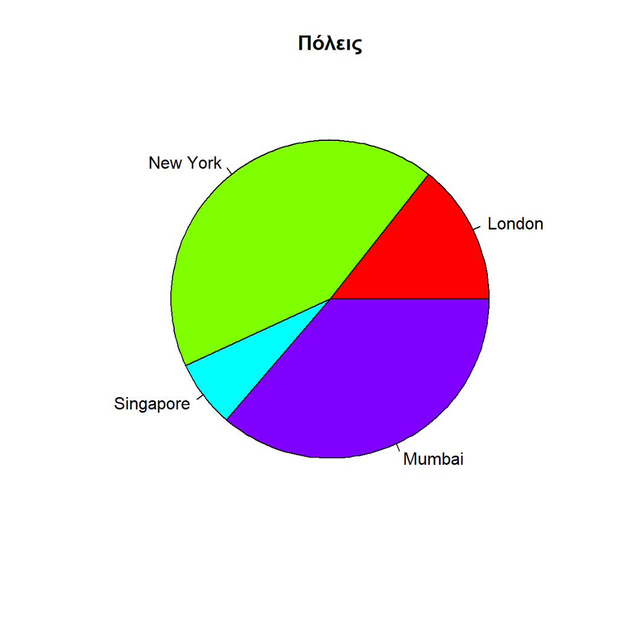

```r
# Σχεδιασμός πίτας.
pie(x, labels, main = "Πόλεις", col = rainbow(length(x)))
```

Μπορούμε να προσθέσουμε κάποιες επιπλέον παραμέτρους, όπως να συμπεριλάβουμε το ποσοστό επί του συνόλου σαν ετικέτα, υπολογίζοντας την μεταβλητή `piepercent` και να ορίσουμε το μέγεθος του επεξηγηματικού πλαισίου `legend` με τη μεταβλητή `cex`.

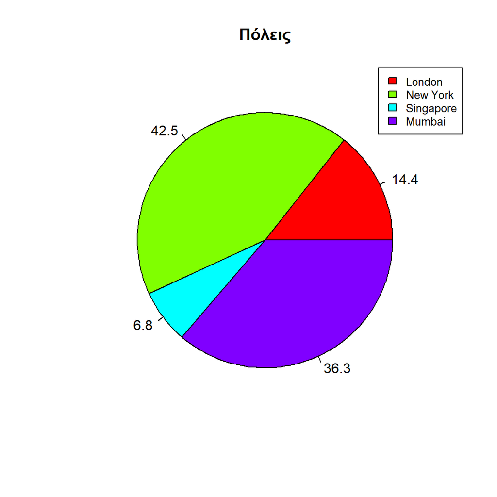

```r
piepercent<- round(100*x/sum(x), 1)
pie(x, labels = piepercent, main = "Πόλεις",col = rainbow(length(x)))
legend("topright", c("London","New York","Singapore","Mumbai"), cex = 0.8,
   fill = rainbow(length(x)))
```

**3D γράφημα πίτας** Ένα γράφημα πίτας με 3 διαστάσεις μπορεί να σχεδιαστεί χρησιμοποιώντας πρόσθετα πακέτα. Το πακέτο `plotrix` έχει μια συνάρτηση που ονομάζεται `pie3D ()` που χρησιμοποιείται για αυτό.

```
install.packages("plotrix")
library(plotrix)
```

```
pie3D(x,labels = labels,labelcex=0.8,explode = 0.1, main = "Χώρες",shade=0.5)
```

## Γραφήματα ράβδων

Ένα γράφημα ράβδων αντιπροσωπεύει δεδομένα σε ορθογώνιες ράβδους με μήκος της ράβδου ανάλογο με την τιμή της μεταβλητής. Το R χρησιμοποιεί τη συνάρτηση `barplot ()` για τη δημιουργία γραφημάτων. H R μπορεί να σχεδιάσει τόσο κάθετες όσο και οριζόντιες ράβδους στο γράφημα ράβδων.

Η βασική σύνταξη για τη δημιουργία ενός ραβδόγραμμα στο R είναι

`barplot(H,xlab,ylab,main, names.arg,col)` Όπου :

**H** είναι ένα διάνυσμα ή matrix που περιέχει αριθμητικές τιμές που χρησιμοποιούνται στο γράφημα ράβδων. **xlab** είναι η ετικέτα για τον άξονα x. **ylab** είναι η ετικέτα για τον άξονα y. **main** είναι ο τίτλος του ραβδογράμματος. **names.arg** είναι ένα διάνυσμα ονομάτων που εμφανίζονται κάτω από κάθε γραμμή. **col** χρησιμοποιείται για να δώσει χρώματα στις γραμμές του γραφήματος.

**Παράδειγμα**

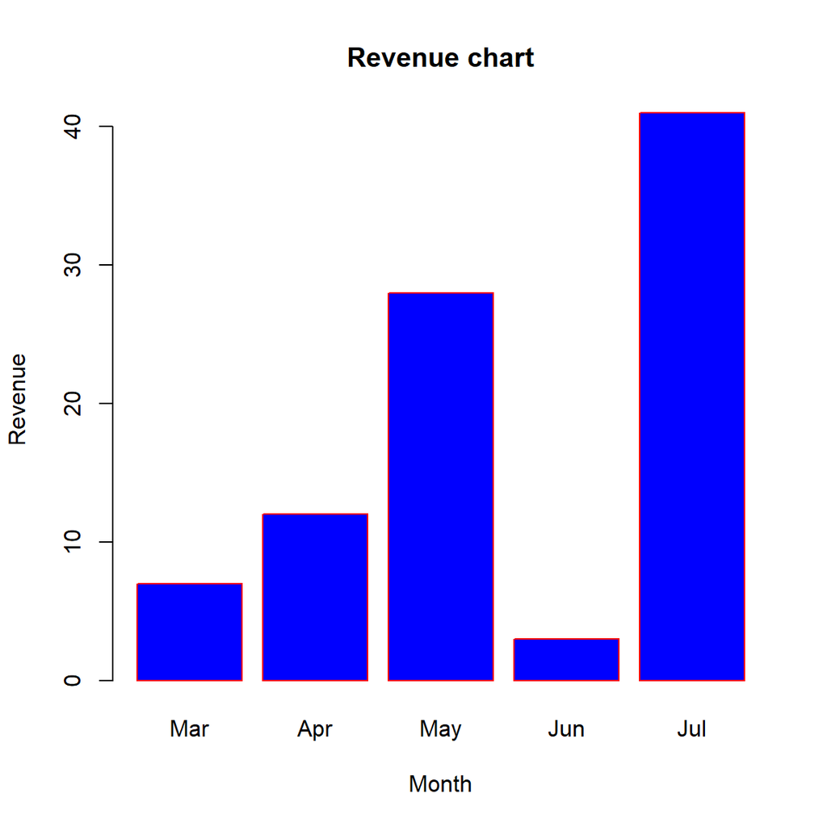

```r
# Δημιουργούμε ένα απλό γράφημα ράβδων χρησιμοποιώντας μόνο το διάνυσμα εισαγωγής και το όνομα κάθε ράβδου.
H <- c(7,12,28,3,41)
M <- c("Mar","Apr","May","Jun","Jul")

# Σχεδιασμός Γραφήματος
barplot(H,names.arg=M,xlab="Month",ylab="Revenue",col="blue",
main="Revenue chart",border="red")
```

Μπορούμε να δημιουργήσουμε γράφημα ράβδων με ομάδες ράβδων και στοίβες σε κάθε γραμμή χρησιμοποιώντας έναν πίνακα ως τιμές εισόδου.

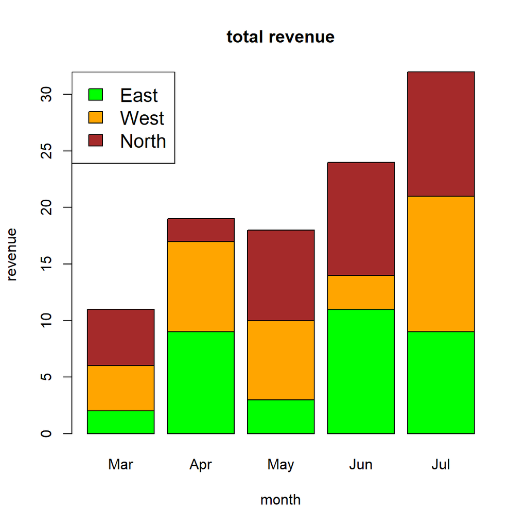

```r
# Διανύσματα
colors = c("green","orange","brown")
months <- c("Mar","Apr","May","Jun","Jul")
regions <- c("East","West","North")
#Τιμές
Values <- matrix(c(2,9,3,11,9,4,8,7,3,12,5,2,8,10,11), nrow = 3, ncol = 5, byrow = TRUE)
#Σχεδιασμός  Ραβδογράμματος
barplot(Values, main = "total revenue", names.arg = months, xlab = "month", ylab = "revenue", col = colors)
legend("topleft", regions, cex = 1.3, fill = colors)
```

## Boxplots

Στα περιγραφικά στατιστικά στοιχεία, η γραφική παράσταση κουτιού είναι μια μέθοδος για την γραφική απεικόνιση ομάδων αριθμητικών δεδομένων μέσω των τεταρτημορίων τους. Τα γραφήματα κουτιού μπορεί επίσης να έχουν γραμμές που εκτείνονται από τα κουτιά που δείχνουν μεταβλητότητα έξω από τα άνω και κάτω τεταρτημόρια, εξ ου και οι όροι διάγραμμα box-and-whisker plot και box-and-whisker diagram.

Τα `boxplots` δημιουργούνται στην R χρησιμοποιώντας τη συνάρτηση `boxplot ()` .

Η βασική σύνταξη για τη δημιουργία ενός `boxplot` είναι:

```
boxplot(x, data, notch, varwidth, names, main)
```

Όπου :

`x` είναι ένα διάνυσμα ή ένας τύπος.

`data` είναι το πλαίσιο δεδομένων.

`notch` είναι μια λογική τιμή. Ορίστε ως Αληθινή για να σχεδιάσετε μια εγκοπή.

`varwidth` είναι μια λογική τιμή. Ορίστε ως αληθές για να σχεδιάσετε το πλάτος του κουτιού ανάλογα με το μέγεθος του δείγματος.

`names` είναι οι ομαδικές ετικέτες που θα εκτυπωθούν κάτω από κάθε πλαίσιο.

`main` χρησιμοποιείται για να δώσει έναν τίτλο στο γράφημα.

**Παράδειγμα**

Χρησιμοποιούμε το σύνολο δεδομένων `mtcars` που είναι διαθέσιμο στο περιβάλλον R για να δημιουργήσουμε ένα βασικό `boxplot` και επιλέγουμε να δούμε τις στήλες `mpg` και `cyl`.

```r
input <- mtcars[,c('mpg','cyl')]
print(head(input))
```

```
                   mpg cyl
Mazda RX4         21.0   6
Mazda RX4 Wag     21.0   6
Datsun 710        22.8   4
Hornet 4 Drive    21.4   6
Hornet Sportabout 18.7   8
Valiant           18.1   6
```

**Δημιουργία του Boxplot**

Το παρακάτω σενάριο θα δημιουργήσει ένα γράφημα `boxplot` για τη σχέση μεταξύ mpg (μίλια ανά γαλόνι) και cyl (αριθμός κυλίνδρων).

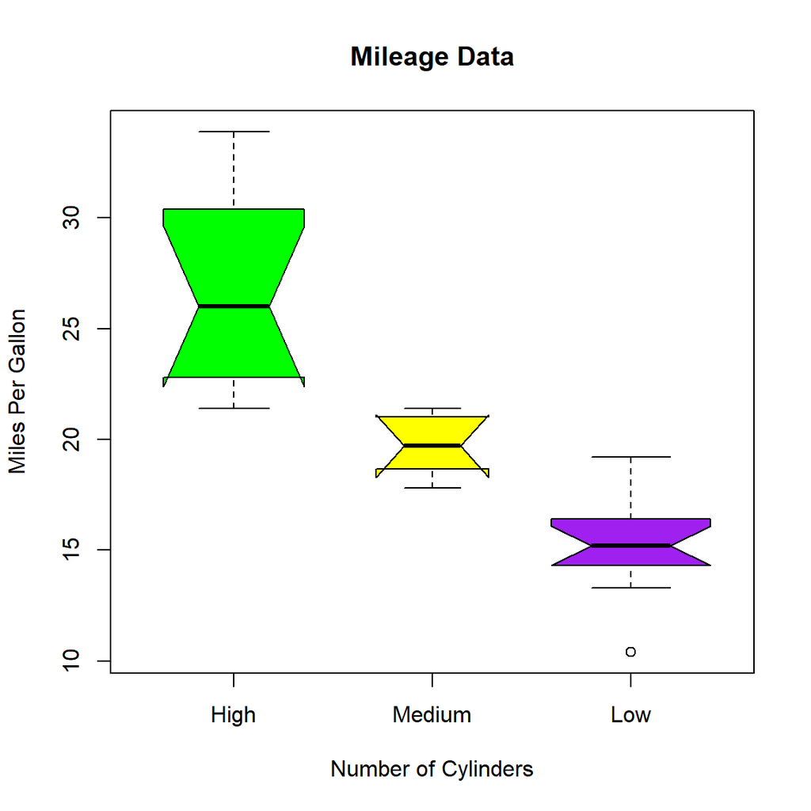

```r
# Σχεδιασμός διαγράμματος.
boxplot(mpg ~ cyl, data = mtcars,
   xlab = "Number of Cylinders",
   ylab = "Miles Per Gallon",
   main = "Mileage Data",
   notch = TRUE,
   varwidth = TRUE,
   col = c("green","yellow","purple"),
   names = c("High","Medium","Low")
)
```

## Ιστογράμμα - Histograms

Ένα ιστόγραμμα αντιπροσωπεύει τις συχνότητες των τιμών μιας μεταβλητής που έχει ενσωματωθεί σε περιοχές. Το ιστόγραμμα είναι παρόμοιο με το ραβδόγραμμα, αλλά η διαφορά είναι ότι ομαδοποιεί τις τιμές σε συνεχή εύρη. Κάθε γραμμή στο ιστόγραμμα αντιπροσωπεύει το ύψος του αριθμού των τιμών που υπάρχουν σε αυτό το εύρος.

Στην R η δημιουργία ιστόγραμματων γίνετε με τη συνάρτηση `hist ()`. Η βασική σύνταξη για τη δημιουργία ιστογράμματος με χρήση του R είναι:

`hist(v,main,xlab,xlim,ylim,breaks,col,border)` όπου :

`V` είναι ένα διάνυσμα που περιέχει αριθμητικές τιμές που χρησιμοποιούνται στο ιστόγραμμα.

`main` δείχνει τον τίτλο του γραφήματος.

`col` χρησιμοποιείται για τον καθορισμό του χρώματος των ράβδων.

`border` χρησιμοποιείται για να ορίσετε το χρώμα περιγράμματος κάθε ράβδου.

`xlab` χρησιμοποιείται για να δώσει περιγραφή του άξονα x.

`xlim` χρησιμοποιείται για τον καθορισμό του εύρους τιμών στον άξονα x.

`ylim` χρησιμοποιείται για τον καθορισμό του εύρους τιμών στον άξονα y.

`breaks` χρησιμοποιείται για να δημιουργήσει κενά μεταξύ.

**Παράδειγμα**

```r
#δημιουργία διανύσματος
v <-  c(9,13,21,8,36,22,12,41,31,33,19)
```

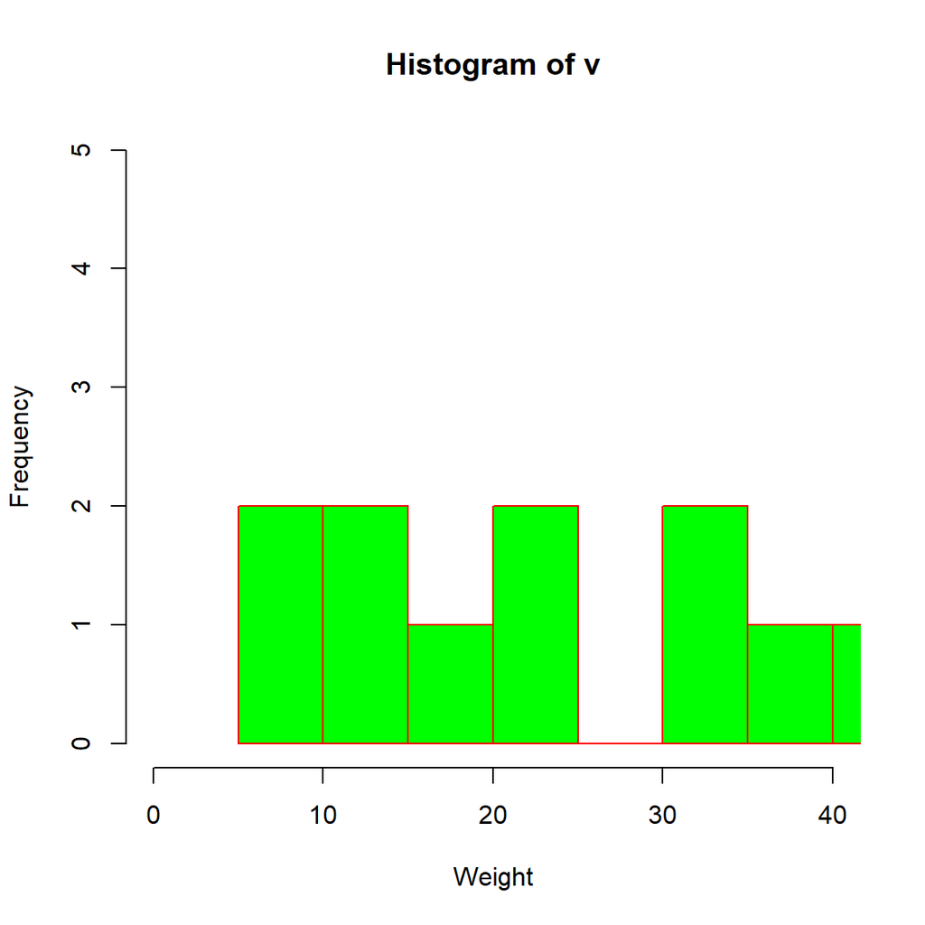

```r
#Δημιουργία Ιστογράμματος
hist(v,xlab = "Weight",col = "green",border = "red", xlim = c(0,40), ylim = c(0,5),
   breaks = 5)
```

# Μάθημα 8ο - Οπτικοποίηση δεδομένων

## Οπτικοποίηση δεδομένων

Η R έχει πολλά συστήματα για τη δημιουργία γραφημάτων, αλλά το `ggplot2` είναι ένα από τα πιο κομψά και πιο ευέλικτα. Το `ggplot2` εφαρμόζει τη γραμματική των γραφικών , ένα συνεκτικό σύστημα για την περιγραφή και τη δημιουργία γραφημάτων. Το `ggplot2` είναι ένα από τα βασικά μέλη του `tidyverse`. Για να αποκτήσετε πρόσβαση στα σύνολα δεδομένων, τις σελίδες βοήθειας και τις λειτουργίες που θα χρησιμοποιήσουμε , φορτώστε το `tidyverse` εκτελώντας αυτόν τον κωδικό:

```r
install.packages("tidyverse",repos = "http://cran.us.r-project.org")
library(tidyverse)
```

Θα χρησιμοποιήσουμε δεδομένα του dataset `mpg`. Για να γίνει πιο κατανοητη η ανάλυση των γραφημάτων θα εφαρμόσουμε κάποια ερωτήματα στα δεδομένα μας και θα αναζητήσουμε απαντήσεις στην εμφάνιση των γραφημάτων :

1. Τα αυτοκίνητα με μεγάλους κινητήρες χρησιμοποιούν περισσότερα καύσιμα από τα αυτοκίνητα με μικρούς κινητήρες;

Τώρα θα προσπαθήσουμε να απαντήσουμε χρησημοποιώντας το dataset `mpg`, που περιλαμβάνει παρατηρήσεις που συλλέγονται από την Αμερικανική Υπηρεσία Προστασίας Περιβάλλοντος για 38 μοντέλα αυτοκινήτων. Θα διευρευνίσουμε πώς φαίνεται η σχέση μεταξύ του μεγέθους του κινητήρα και της απόδοσης καυσίμου; Είναι θετικό; Αρνητικό; Γραμμικό; Μη γραμμικό;

```
mpg
```

Θα χρησιμοποιήσουμε την μεταβλητή `displ`, που αφορά το μέγεθος του κινητήρα ενός αυτοκινήτου, σε λίτρα και την μεταβλητή `hwy` , που αφορά την απόδοση καυσίμου ενός αυτοκινήτου στον αυτοκινητόδρομο, σε μίλια ανά γαλόνι (mpg). Ένα αυτοκίνητο με χαμηλή απόδοση καυσίμου καταναλώνει περισσότερο καύσιμο από ένα αυτοκίνητο με υψηλή απόδοση καυσίμου όταν ταξιδεύουν στην ίδια απόσταση.

Για να μάθετε περισσότερα για το dataset `mpg`, ανοίξτε τη σελίδα βοήθειας εκτελώντας `?mpg`.

**Δημιουργία ggplot**

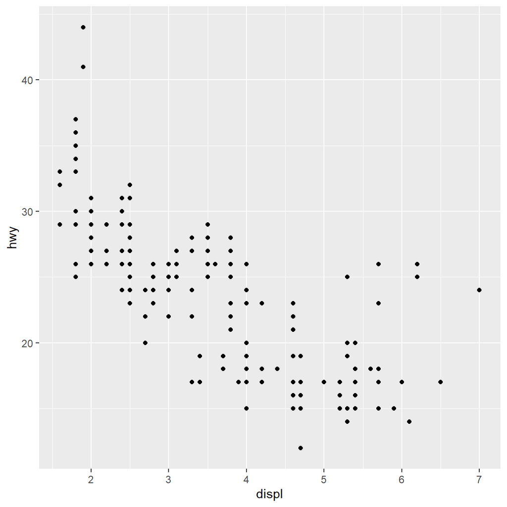

```r
ggplot(data = mpg) +
  geom_point(mapping = aes(x = displ, y = hwy))
```

Το διάγραμμα δείχνει μια αρνητική σχέση μεταξύ του μεγέθους του κινητήρα ( `displ`) και της απόδοσης καυσίμου ( `hwy`). Με άλλα λόγια, τα αυτοκίνητα με μεγάλους κινητήρες χρησιμοποιούν περισσότερα καύσιμα.

Η συνάρτηση `geom_point()` προσθέτει **επίπεδα** στην πλοκή του διαγράμματος. Το `ggplot2` συνοδεύεται από πολλές συναρτήσεις `geom` που η καθέ μία προσθέτει διαφορετικό τύπο επιπέδου σε μια πλοκή. Το `aes()` αφορά τα x και y ορίσματα , τις συνεταταγμένες του διαγράμματος.

Ένας γενικός τύπος σύνταξης της ggplot είναι : `ggplot(data = <DATA>) +` `<GEOM_FUNCTION>(mapping = aes(<MAPPINGS>))`

Ας υποθέσουμε ότι τα αυτοκίνητα είναι υβριδικά. Ένας τρόπος για να δοκιμάσετε αυτήν την υπόθεση είναι να κοιτάξετε την `class` τιμή για κάθε αυτοκίνητο. Η `class` μεταβλητή του `mpg` συνόλου δεδομένων ταξινομεί τα αυτοκίνητα σε ομάδες όπως compact, μεσαίο μέγεθος και SUV. Εάν τα απομακρυσμένα σημεία είναι υβρίδικα, θα πρέπει να ταξινομηθούν ως compact αυτοκίνητα ή, ίσως, αυτοκίνητα subcompact.

Μπορείτε να προσθέσετε μια τρίτη μεταβλητή, όπως η `class`, σε ένα δισδιάστατο `scatterplot`, αλλάζοντας τα ορίσματα της `aes()` . Η αισθητική είναι μια οπτική ιδιότητα των αντικειμένων στην πλοκή σας. Η αισθητική περιλαμβάνει πράγματα όπως το μέγεθος, το σχήμα ή το χρώμα των σημείων σας. Μπορείτε να εμφανίσετε ένα σημείο με διαφορετικούς τρόπους αλλάζοντας τις τιμές των αισθητικών ιδιοτήτων του. Μπορούμε να αλλάζουμε τα επίπεδα μεγέθους, σχήματος και χρώματος ενός σημείου για να κάνουμε το σημείο μικρό, τριγωνικό ή μπλε:

**Παράδειγμα**

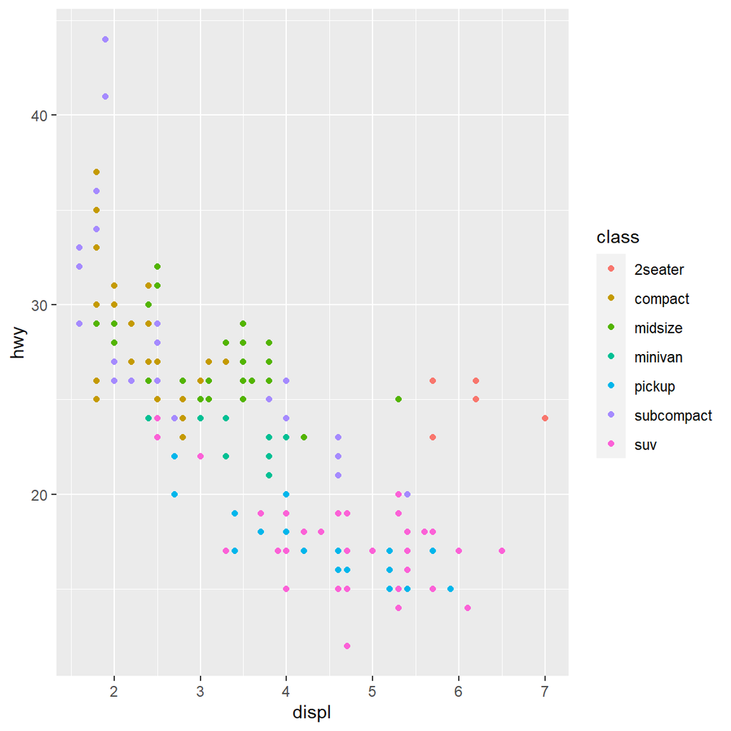

```r
ggplot(data = mpg) +
  geom_point(mapping = aes(x = displ, y = hwy, colour = class))
```

Για να χαρτογραφήσετε μια αισθητική σε μια μεταβλητή, συσχετίστε το όνομα της αισθητικής με το όνομα της μεταβλητής στην `aes()`. ο ggplot2 θα εκχωρήσει αυτόματα ένα μοναδικό επίπεδο αισθητικής (ένα μοναδικό χρώμα) σε κάθε μοναδική τιμή της μεταβλητής, μια διαδικασία γνωστή ως κλιμάκωση . Το `ggplot2` θα προσθέσει επίσης λεζάντα που εξηγεί ποια επίπεδα αντιστοιχούν, σε ποιες τιμές.

Στο παραπάνω παράδειγμα, χαρτογραφήσαμε την μεταβλητή `class` , αλλά θα μπορούσαμε να αντιστοιχίσουμε την `class` με αλλαγή μεγέθους με τον ίδιο τρόπο. Σε αυτήν την περίπτωση, το ακριβές μέγεθος κάθε σημείου θα αποκάλυπτε την ταξική τους σχέση. Λαμβάνουμε μια προειδοποίηση εδώ, γιατί η αντιστοίχιση μιας μη ταξινομημένης μεταβλητής ( `class`) σε μια ταξινομημένη αισθητική ( `size`) δεν είναι καλή ιδέα.

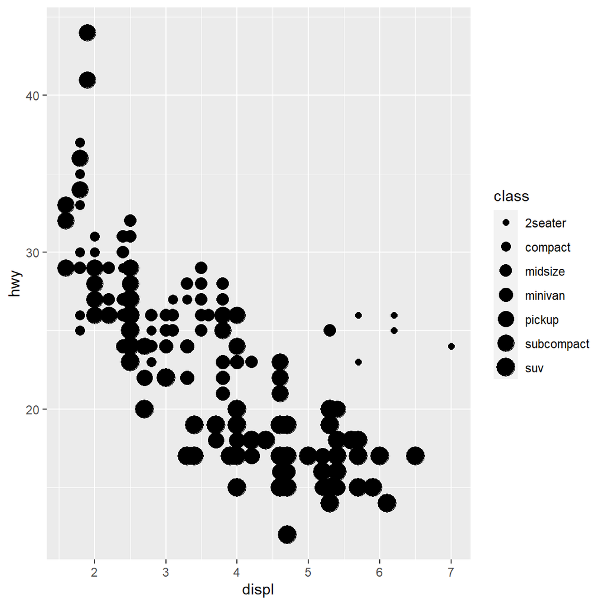

```r
ggplot(data = mpg) +
  geom_point(mapping = aes(x = displ, y = hwy, size = class))
```

Ή θα μπορούσαμε να αντιστοιχίσουμε την `class` με το όσισμα alpha , η οποία ελέγχει τη διαφάνεια των σημείων,

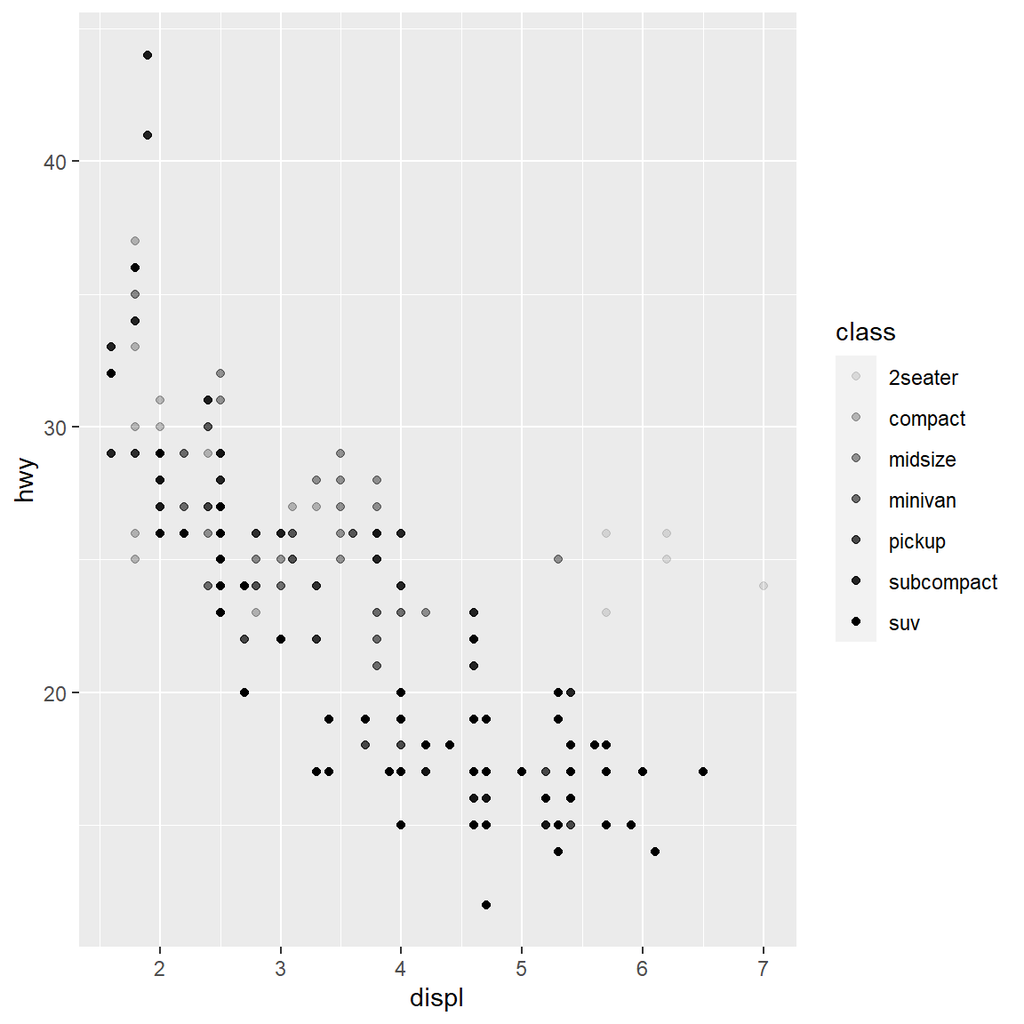

```r
ggplot(data = mpg) +
  geom_point(mapping = aes(x = displ, y = hwy, alpha = class))
```

ή με το όρισμα shape , το οποίο οποία ελέγχει το σχήμα των σημείων.

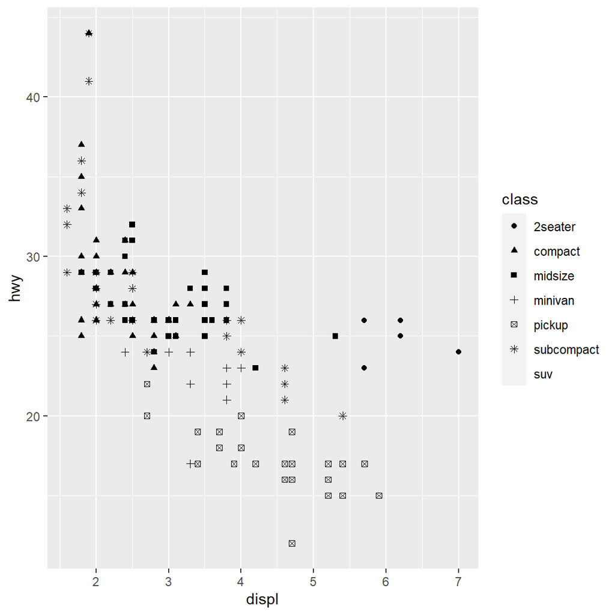

```r
ggplot(data = mpg) +
  geom_point(mapping = aes(x = displ, y = hwy, shape = class))
```

Το `ggplot2` θα χρησιμοποιεί μόνο έξι σχήματα κάθε φορά. Από προεπιλογή, οι πρόσθετες ομάδες απορρίπτονται.

**Διερεύνσηση προβλημάτων** 1) Τι πήγε στραβά με αυτόν τον κώδικα; Γιατί τα σημεία δεν είναι μπλε;

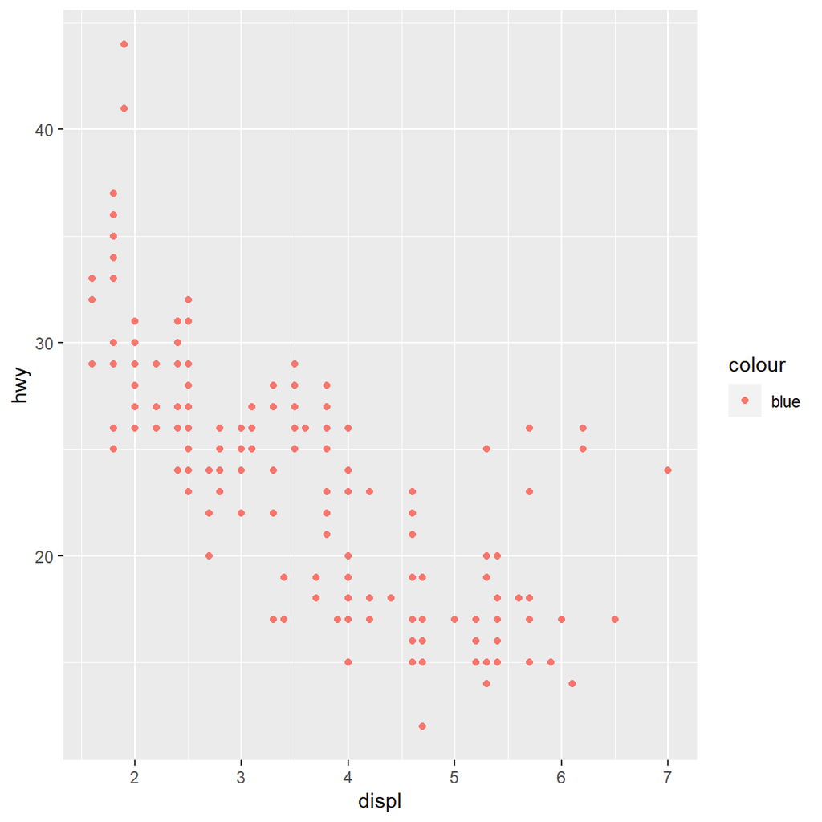

```r
ggplot(data = mpg) +
  geom_point(mapping = aes(x = displ, y = hwy, color = "blue"))
```

Το `colour = "blue"` περιλαμβάνεται στο `mapping`, στο όρισμα `aes()`. Συνεπώς η έκφραση, colour = “blue”, “blue” ερμηνεύεται ως κατηγορική μεταβλητή η οποία λαμβάνει μόνο μία απλή τιμή “blue”. Η λύση είναι να βγεί από το όρισμα `aes()`.

```
ggplot(data = mpg) +
  geom_point(mapping = aes(x = displ, y = hwy), color = "blue")
```

2. Ποιες μεταβλητές `mpg` είναι κατηγορηματικές και ποιες είναι συνεχείς; (Συμβουλή: πληκτρολογήστε `??mpg` για να διαβάσετε την τεκμηρίωση για το σύνολο δεδομένων). Πώς μπορείτε να δείτε αυτές τις πληροφορίες όταν εκτελείτε `mpg`;

Όσες μεταβλητές έχουν `<chr>` πάνω από τις στήλες τους είναι κατηγορηματικές, ενώ με `<dbl>` ή `<int>` είναι συνεχείς. Η `glimpse()` είναι μια άλλη συνάρτηση που εμφανίζει συνοπτικά τον τύπο κάθε στήλης στο πλαίσιο δεδομένων:

```
glimpse(mpg)
```

Συνεχής μεταβλητή με color, size και shape. Πώς συμπεριφέρονται οι κατηγορηματικές έναντι συνεχών μεταβλητών;

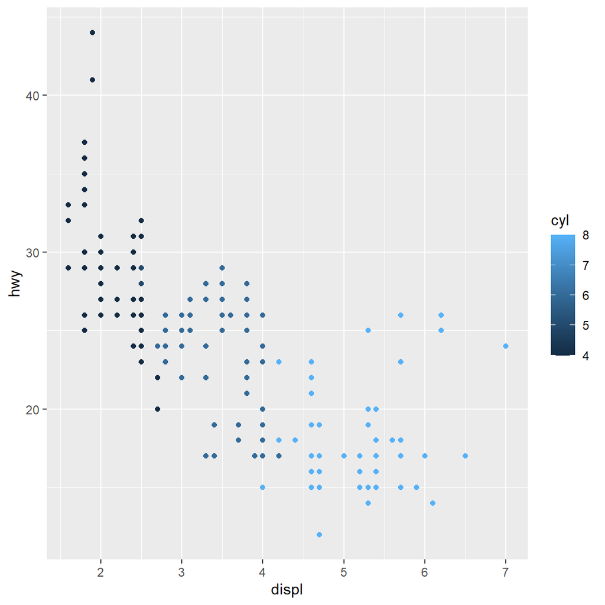

```r
ggplot(data = mpg) +
  geom_point(mapping = aes(x = displ, y = hwy, color = cyl  ))
```

Τι συμβαίνει εάν αντιστοιχίσετε την ίδια μεταβλητή σε πολλαπλή αισθητική;

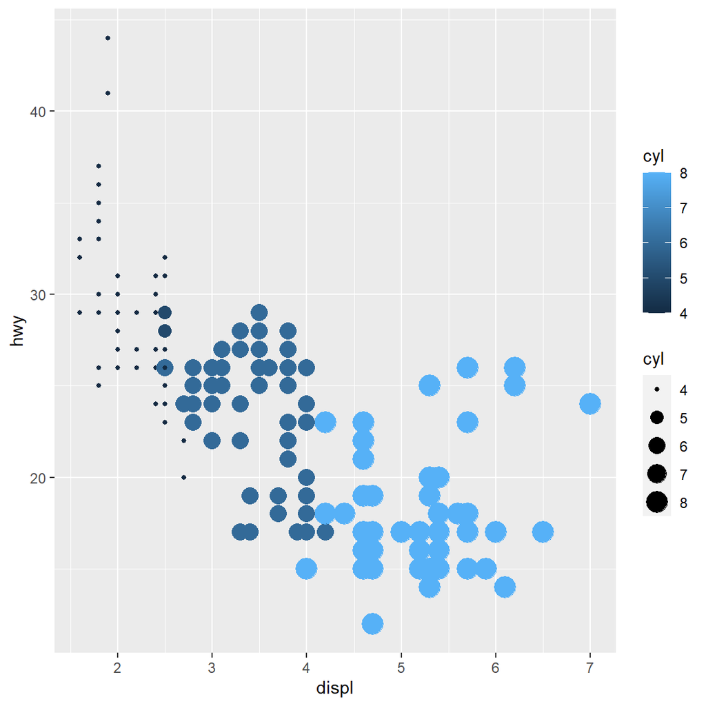

```r
ggplot(data = mpg) +
  geom_point(mapping = aes(x = displ, y = hwy, color = cyl,size=cyl  ))
```

Τι κάνει η stroke ; (Συμβουλή: χρήση ?geom_point)

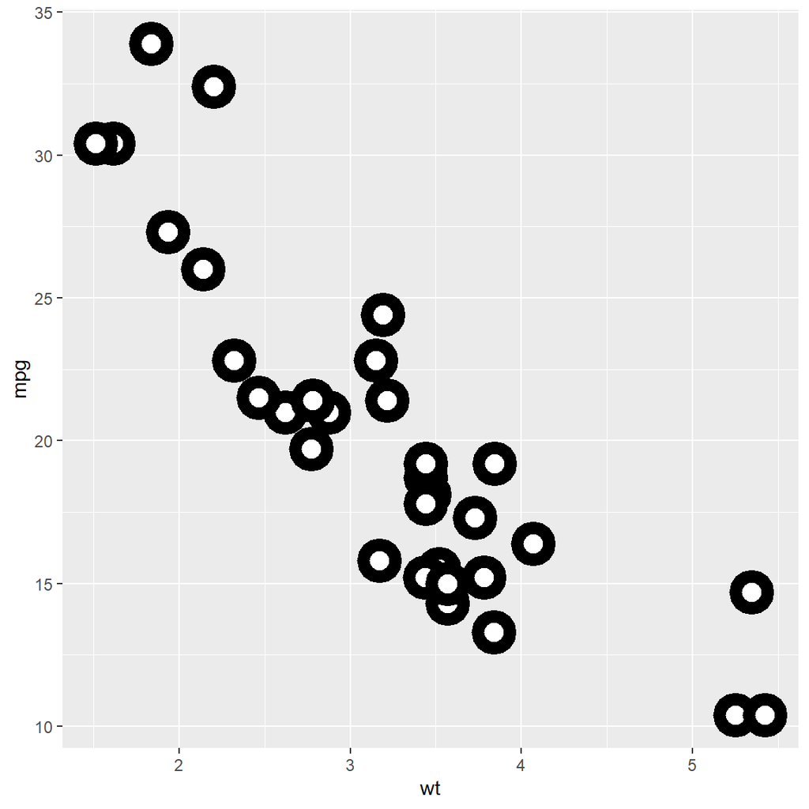

```r
#αλλάζει το μέγεθος του περιγράμματος
ggplot(mtcars, aes(wt, mpg)) +
  geom_point(shape = 21, colour = "black", fill = "white", size = 5, stroke = 5)
```

Τι συμβαίνει αν χαρτογραφήσετε μια αισθητική σε κάτι διαφορετικό από ένα μεταβλητό όνομα, όπως `aes(colour = displ < 5)`;

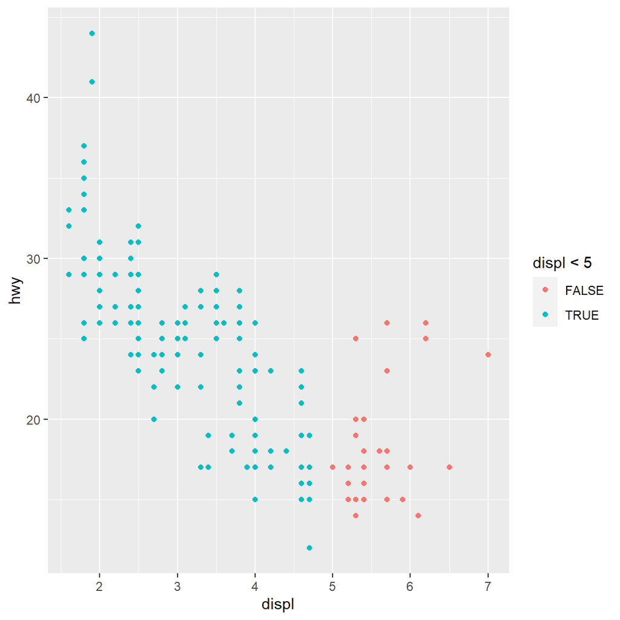

```r
ggplot(mpg, aes(x = displ, y = hwy, colour = displ < 5)) +
  geom_point()
```

**Όψεις** Ένας τρόπος για να προσθέσετε επιπλέον μεταβλητές είναι με την αισθητική. Ένας άλλος τρόπος, ιδιαίτερα χρήσιμος για κατηγορηματικές μεταβλητές, είναι να χωρίσετε την πλοκή σας σε υποπεριοχές που κάθε ένα εμφανίζει ένα υποσύνολο των δεδομένων.

Για να τοποθετήσετε την πλοκή σας με μία μόνο μεταβλητή, χρησιμοποιήστε το `facet_wrap()`.

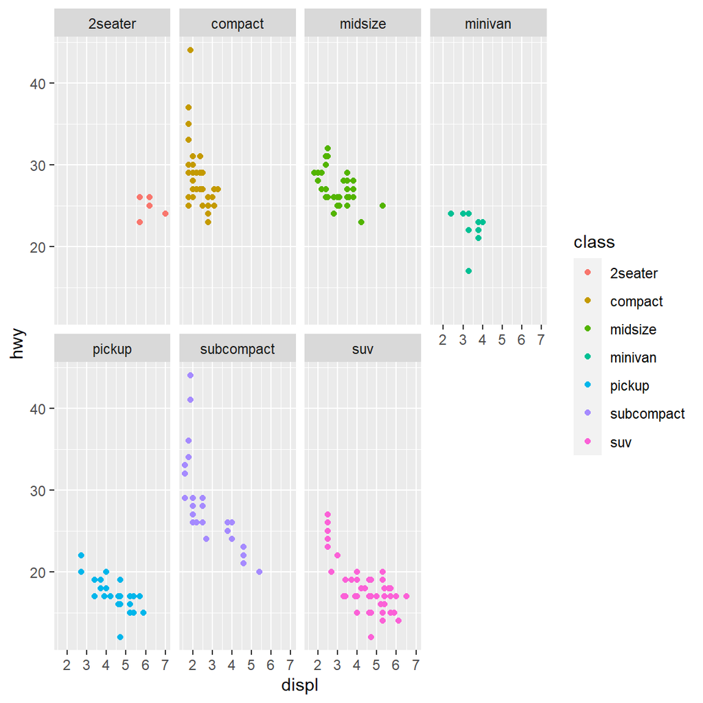

```r
ggplot(data = mpg) +
  geom_point(mapping = aes(x = displ, y = hwy, color =class))+
   facet_wrap(~ class, nrow = 2)
```

Για να ενσωματώσετε στην πλοκή σας συνδυασμό δύο μεταβλητών, προσθέστε `facet_grid()` στην κλήση της πλοκής.

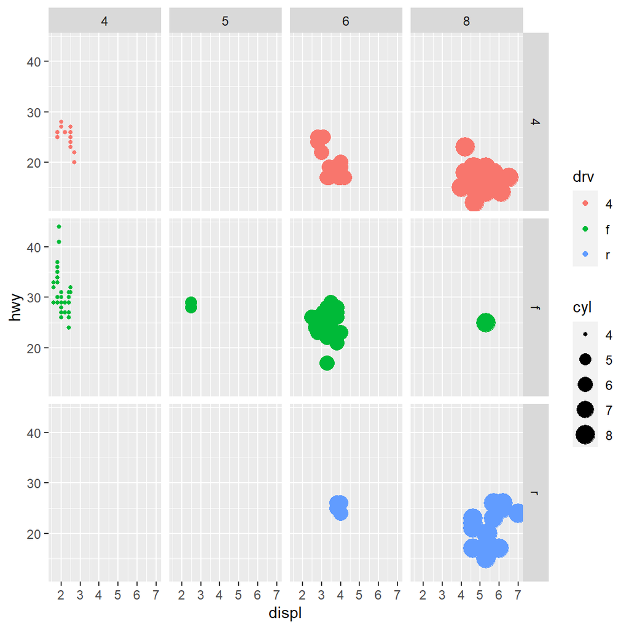

```r
ggplot(data = mpg) +
  geom_point(mapping = aes(x = displ, y = hwy, color=drv, size=cyl)) +
  facet_grid(drv ~ cyl)
```

Αν προτιμάτε να μην διαχωρίζονται οι γραμμές και οι στήλες στη διασταύρωσή τους , χρησιμοποιήστε μία “.” αντί για ένα όνομα μεταβλητής, π.χ. + facet_grid(. ~ cyl).

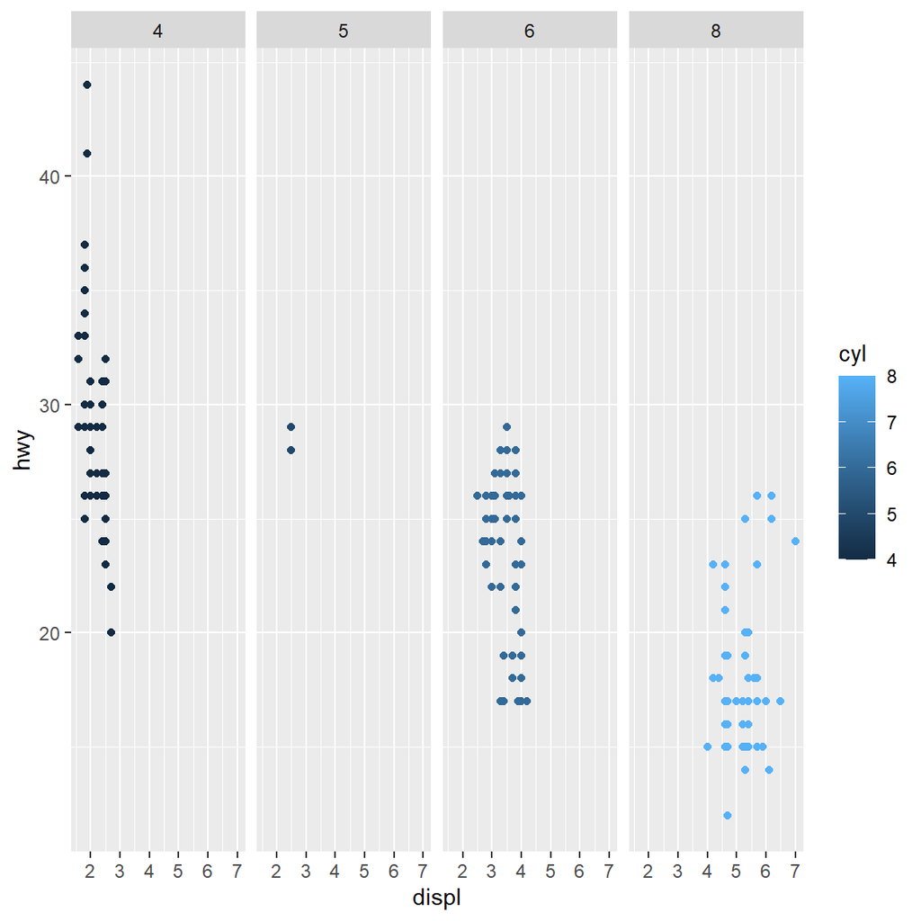

```r
ggplot(data = mpg) +
  geom_point(mapping = aes(x = displ, y = hwy, color=cyl)) +
  facet_grid(.~ cyl)
```

**Γεωμετρικά αντικείμενα**

Κάθε πλοκή μπορεί να χρησιμοποιεί ένα διαφορετικό οπτικό αντικείμενο για την αναπαράσταση των δεδομένων. Στη σύνταξη ggplot2, λέμε ότι χρησιμοποιούν διαφορετικά geom .

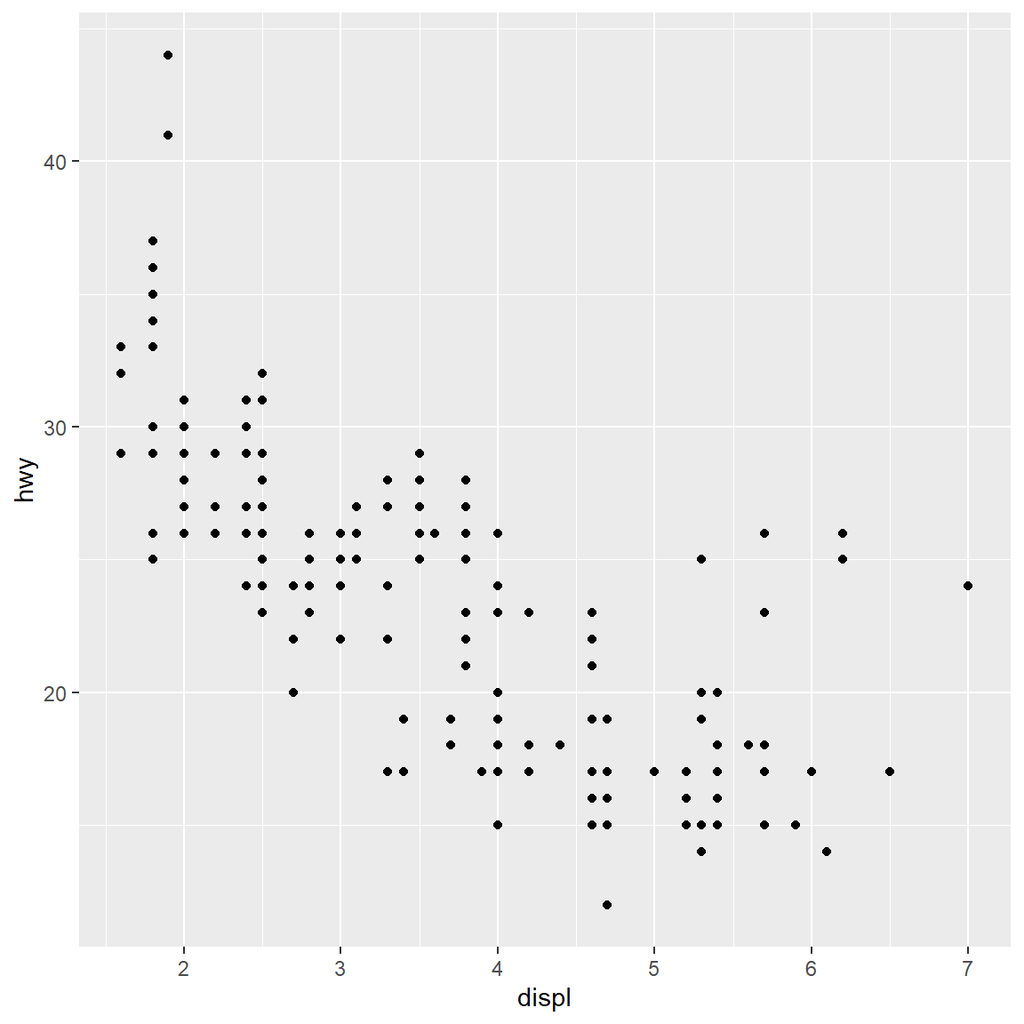

```r
ggplot(data = mpg) +
  geom_point(mapping = aes(x = displ, y = hwy))
```

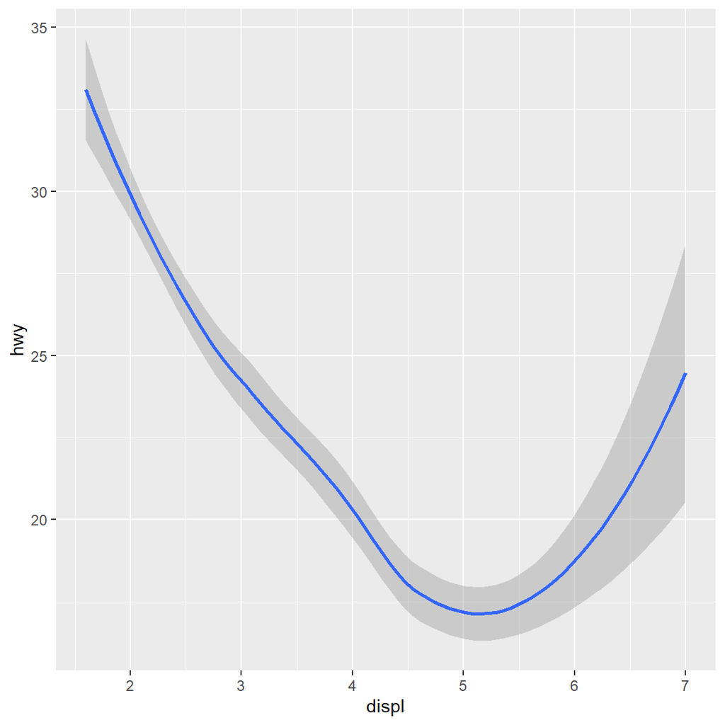

```r
ggplot(data = mpg) +
  geom_smooth(mapping = aes(x = displ, y = hwy))
```

Mπορείτε να ορίσετε το linetype μιας γραμμής στο `geom_smooth()` και θα σχεδιάσει μια διαφορετική γραμμή, με διαφορετικό τύπο linetype, για κάθε μοναδική τιμή της μεταβλητής που αντιστοιχίζετε στο linetype όπως παρακάτω :

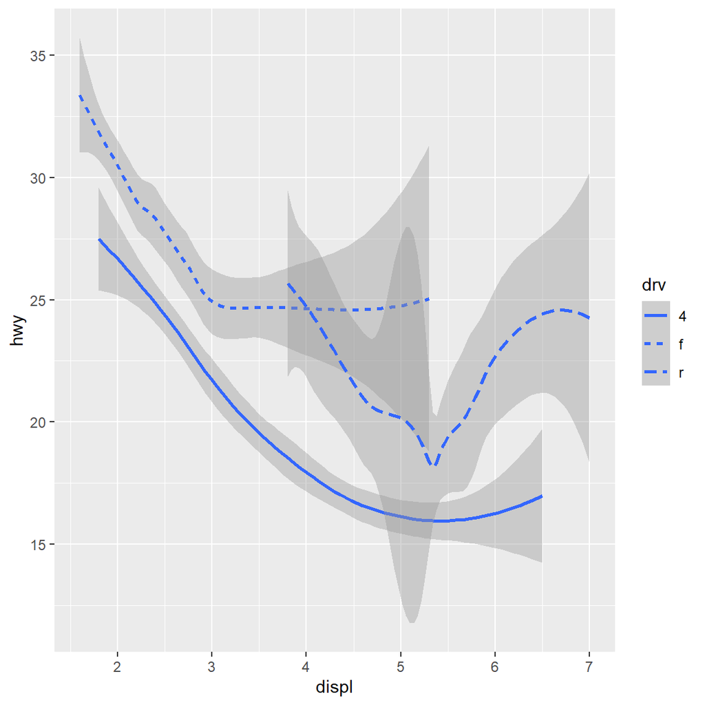

```r
ggplot(data = mpg) +
  geom_smooth(mapping = aes(x = displ, y = hwy, linetype = drv))
```

Εδώ geom_smooth()χωρίζει τα αυτοκίνητα σε τρεις γραμμές με βάση την `drv` μεταβλητή, η οποία περιγράφει το σύστημα μετάδοσης κίνησης ενός αυτοκινήτου. Το 4 σημαίνει τετράτροχη κίνηση, f για κίνηση μπροστά και r για κίνηση πίσω.

Το ggplot2 παρέχει πάνω από 40 geom και τα πακέτα επέκτασης παρέχουν ακόμη περισσότερα (δείτε https://exts.ggplot2.tidyverse.org/gallery/ ). Ο καλύτερος τρόπος για να λάβετε μια ολοκληρωμένη επισκόπηση είναι το cheatsheet ggplot2, το οποίο μπορείτε να βρείτε στη διεύθυνση http://rstudio.com/resources/cheatsheets .

Για να εμφανίσετε πολλά geom στην ίδια γραφική παράσταση, προσθέστε πολλές συναρτήσεις geom στο ggplot() όπως παρακάτω:

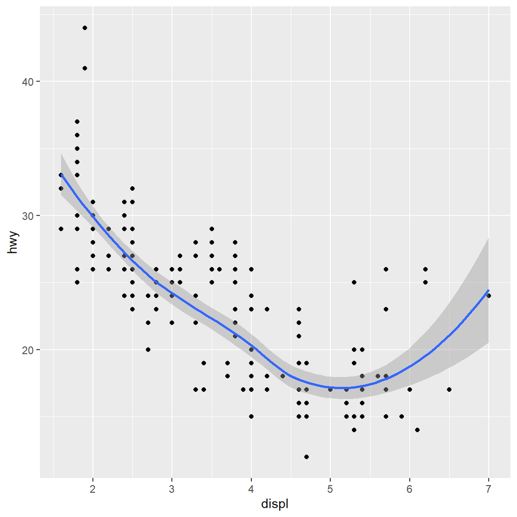

```r
ggplot(data = mpg, mapping = aes(x = displ, y = hwy)) +
  geom_point() +
  geom_smooth()
```

Μπορείτε να χρησιμοποιήσετε την ίδια ιδέα για να καθορίσετε διαφορετικά data για κάθε επίπεδο. Εδώ, η ομαλή γραμμή μας εμφανίζει μόνο ένα υποσύνολο του `mpg`, τα αυτοκίνητα subcompact.

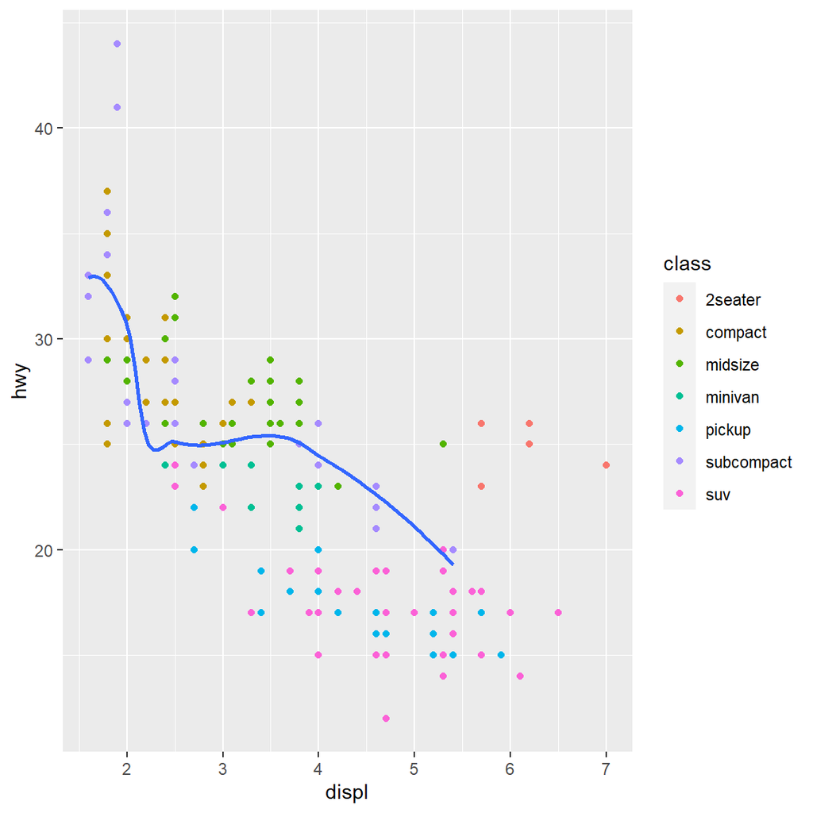

```r
ggplot(data = mpg, mapping = aes(x = displ, y = hwy)) +
  geom_point(mapping = aes(color = class)) +
  geom_smooth(data = filter(mpg, class == "subcompact"), se = FALSE)
```

(https://r4ds.had.co.nz/data-visualisation.html)

# Μάθημα 9ο - Στατιστικά στοιχεία στην R

**Παραδείγματα στατιστικών στοιχείων R**

Σκοπός αυτού του κεφαλαίου είναι να δούμε την απικόνισει βασικών στατιστικών υπολογισμός στην R

## R - Μέσος όρος, διάμεσος

Η στατιστική ανάλυση στην R πραγματοποιείται χρησιμοποιώντας πολλές ενσωματωμένες συναρτήσεις. Οι περισσότερες από αυτές τις λειτουργίες αποτελούν μέρος του βασικού πακέτου R.

**Μέσος Όρος**

Υπολογίζεται λαμβάνοντας το άθροισμα των τιμών και διαιρώντας με τον αριθμό τιμών σε μια σειρά δεδομένων.Ο υπολογισμός στην R γίνετε με την function `mean()` και έχει την παρακάτω σύνταξη :

`mean(x, trim = 0, na.rm = FALSE, ...)`

Όπου :

Το x είναι το διάνυσμα εισαγωγής.

Το trim χρησιμοποιείται για να ρίξει μερικές παρατηρήσεις και από τα δύο άκρα του ταξινομημένου διανύσματος.

Το na.rm χρησιμοποιείται για την αφαίρεση των τιμών που λείπουν από το διάνυσμα εισόδου.

**Παράδειγμα**

```r
# Δημιουργία Διανύσματος
x <- c(12,7,3,4.2,18,2,54,-21,8,-5)
```

```r
# Εύρεση Μέσου όρου
MO <- mean(x)
print(MO)
```

```
[1] 8.22
```

**TRIM**

Όταν παρέχεται η παράμετρος trim, οι τιμές στο διάνυσμα ταξινομούνται και, στη συνέχεια, οι απαιτούμενοι αριθμοί παρατηρήσεων μειώνονται από τον υπολογισμό του μέσου όρου.

Όταν το trim = 0,3, 3 τιμές από κάθε άκρο θα αφαιρεθούν από τους υπολογισμούς πριν την ευρεση του μέσου όρου.

Σε αυτήν την περίπτωση αν το διάνυσμα είναι (−21, −5, 2, 3, 4.2, 7, 8, 12, 18, 54) οι τιμές που αφαιρούνται από το διάνυσμα για τον υπολογισμό του μέσου όρου είναι (−21, −5,2) από αριστερά και (12,18,54) από δεξιά.

```r
x <- c(12,7,3,4.2,18,2,54,-21,8,-5)
MOT <-  mean(x,trim = 0.3)
print(MOT)
```

```
[1] 5.55
```

**Εφαρμογή NA**

Εάν λείπουν τιμές, τότε η συνάρτηση mean() επιστρέφει NA.

Για να απορρίψετε τις τιμές που λείπουν από τον υπολογισμό χρησιμοποιήστε na.rm = TRUE. που σημαίνει αφαίρεση των τιμών NA.

```r
x <- c(12,7,3,4.2,18,2,54,-21,8,-5,NA)
MONA <-  mean(x)
print(MONA)
```

```
[1] NA
```

```r
x <- c(12,7,3,4.2,18,2,54,-21,8,-5,NA)
MONA <-  mean(x,na.rm = TRUE)
print(MONA)
```

```
[1] 8.22
```

**Διάμεσος - Median** https://www.investopedia.com/terms/m/median.asp Η διάμεσος είναι ο μεσαίος αριθμός σε μια ταξινομημένη, αύξουσα ή φθίνουσα, λίστα αριθμών και μπορεί να είναι πιο περιγραφική αυτού του συνόλου δεδομένων από τον μέσο όρο. Εάν υπάρχει περίεργος αριθμός αριθμών, η διάμεση τιμή είναι ο αριθμός που βρίσκεται στη μέση, με τον ίδιο αριθμό αριθμών παρακάτω και πάνω.

Στην R για τον υπολογισμό χρησιμοποιούμε την συνάρτηση median(). Η βασική σύνταξη για τον υπολογισμό της διάμεσης στο R είναι `median(x, na.rm = TRUE)` όπου:

Το x είναι το διάνυσμα εισαγωγής.

Το na.rm χρησιμοποιείται για την αφαίρεση των τιμών που λείπουν από το διάνυσμα εισόδου.

```r
x <- c(12,7,3,4.2,18,2,54,-21,8,-5,NA)
Mymed <- median(x,na.rm=TRUE)
print(Mymed)
```

```
[1] 5.6
```